# Algebraic Number Theory

# 23 Ch. 20: Unit Theorem, Part II

We still need to prove that this is an equality. We’ll start with some geometric preliminaries.

The **Minkowski embedding** of $K$ is the map
$$\begin{align*}
\iota: K &\to {\mathbb{R}}^{r_1} \times {\mathbb{C}}^{r_2} \\
\alpha &\mapsto {\left[ {
\sigma_1(\alpha), \cdots, \sigma_{r_1}( \alpha),
\sigma_{r_1 + 1}( \alpha), \cdots, \sigma_{r_1 + r_2}( \alpha)
} \right]}
.\end{align*}
Identify \({\mathbb{C}}\cong {\mathbb{R}}^2\) using \(a+bi \mapsto {\left[ {a, b} \right]}\), which identifies the codomain above with \({\mathbb{R}}^{r_1} \times {\mathbb{R}}^{2r_2} = {\mathbb{R}}^n\). So we view \(\iota:K\to {\mathbb{R}}^n\).$$

Note $\iota$ is injective and ${\mathbb{Q}}{\hbox{-}}$linear.

$\iota({\mathbb{Z}}_K)$ is a lattice of full rank in ${\mathbb{R}}^n$.

Why is this a lattice? We’ll show it’s a discrete subgroup.

Let $R>0$, then if $\alpha\in {\mathbb{Z}}_K$ and $\iota(\alpha) \in B_R(0)$, then ${\left\lvert {\sigma( \alpha)} \right\rvert} \leq R$ for all $\sigma: K\hookrightarrow{\mathbb{C}}$. This forces $\alpha$ to be a root of one of finitely many polynomials in $P_{n, R}$.

Now let $g\mathrel{\vcenter{:}}=\operatorname{rank}\iota({\mathbb{Z}}_K)$ as a lattice. This is a free abelian group of rank $g$, so isomorphic to ${\mathbb{Z}}^g$ since it’s the ${\mathbb{Z}}{\hbox{-}}$span of $g$ linearly independent elements. On the other hand, by the integral basis theorem, ${\mathbb{Z}}_K$ is a free abelian group of rank $n$. Since $\iota$ is injective, $\iota({\mathbb{Z}}_K)$ is free of rank $n$, and a fact from algebra implies $n=g$.

Since $\iota({\mathbb{Z}}_K$ is a full rank lattice, $\operatorname{covol}\iota({\mathbb{Z}}_K)$ is well-defined, where the covolume is the volume of the fundamental parallelepiped spanned by any generating set, and is measured by the absolute value of the determinant of the matrix of basis elements. It turns out that the covolume is the discriminant from before, but we don’t need the exact value at the moment.

We’ll now make some further reductions. Recall that $g\mathrel{\vcenter{:}}=\operatorname{rank}\operatorname{Log}({\mathbb{Z}}_K^{\times}) = \dim_{\mathbb{R}}V$, where $V$ is the smallest subspace of ${\mathbb{R}}^{r_1 + r_2}$ containing $\operatorname{Log}({\mathbb{Z}}_K^{\times})$. Recall the rank-nullity theorem:
$$\begin{align*}
\dim_{\mathbb{R}}V + \dim_{\mathbb{R}}V^\perp = r_1 + r_2
\implies g = \dim_{\mathbb{R}}V = r_1 + r_2 - \dim_{\mathbb{R}}V^\perp
.\end{align*}
the goal is to show \(\dim_{\mathbb{R}}V^\perp = 1\). We know \(\mathbf{w} \mathrel{\vcenter{:}}={\left[ {1, 1, \cdots, 1} \right]} \in V^\perp\), so it suffices to show every element of \(V^\perp\) is a multiple of \(\mathbf{w}\). Suppose not, then there’s an element of \(V^\perp\) of the form \({\left[ {c_1, c_2 \cdots, c_j, 0} \right]}\) by subtracting a suitable multiple of \(\mathbf{w}\). Not all of the \(c_i\) are zero, since this would mean the original was a multiple of \(\mathbf{w}\). Define a map
\begin{align*}
F: K^{\times}&\to {\mathbb{R}}\\
\alpha&\mapsto {\left[ {c_1, c_2, \cdots c_{r_1 + r_2 - 1}, 0 } \right]} \cdot \operatorname{Log}( \alpha)
.\end{align*}
Now note that \(F({\mathbb{Z}}_K^{\times}) = 0\), since \(V \supseteq \operatorname{Log}({\mathbb{Z}}_K)\).$$

Let $c_1, c_2, \cdots, c_{r_1 + r_2 - 1} \in {\mathbb{R}}$ not all 0. Then if $F$ is defined as above, $F({\mathbb{Z}}_K^{\times}) \neq 0$.

This requires some delicate inequalities, and an application of Minkowski’s convex body theorem.

There is a sequence of nonzero $\alpha\in K$ such that

- ${\left\lvert {F(\alpha)} \right\rvert} \to \infty$, but
- ${\left\lvert {N( \alpha)} \right\rvert} < C_1 = C_1(K, c_1, \cdots, c_{r_1 + r_2 - 1} )$ not depending on $\alpha$.

Note that there are only finitely many ideals of ${\mathbb{Z}}_K$ of norm bounded by any constant $C_1$. We saw this for quadratic fields: if $N(J) = m$, which by Lagrange’s theorem yields $1+1+\cdots 1 = m \equiv 0 \pmod J$. So $m\in J$ and thus $J\bigm|m$. But by unique factorization, any ideal only has finitely many divisors, so there are only finitely many possible values of $m$.

Note also that ${\left\lvert {N( \alpha )} \right\rvert} = N(\left\langle{ \alpha }\right\rangle ) < C_1$, so there are only finitely many such ideals. So given an infinite sequence of $\alpha$s, there are only finitely many different principal ideals they generate. So by the pigeonhole principle, we can pass to a subsequence such that $\left\langle{ a }\right\rangle$ is constant. Note that $F$ can’t be constant on this sequence, since $F(\alpha) \to \infty$, so we can choose $\alpha_1, \alpha_2$ such that
$$\begin{align*}
\left\langle{ \alpha_1 }\right\rangle= \left\langle{ \alpha_2 }\right\rangle \quad\text{but}\quad F(\alpha_1) \neq F(\alpha_2)
.\end{align*}
If this happens, then \(\alpha_1/ \alpha_2 \in {\mathbb{Z}}_K^{\times}\), and
\begin{align*}
F(\alpha_1/ \alpha_2) = F( \alpha_1)- F(\alpha_2) \neq 0
.\end{align*}
So we have \(F({\mathbb{Z}}_K^{\times})\neq 0\), since we’ve found a unit that maps to a nonzero element.$$

# 24 Ch. 20 Continued (Friday, May 21)

Goal of Ch.18: prove that units theorem where the rank is left unspecified, and we proved it for $g$ the rank of a certain lattice. For Ch.20, we want to show $g$ is the right number! Recall the log function:
$$\begin{align*}
\operatorname{Log}: K^{\times}\to {\mathbb{R}}^{r_1 + r_2}
\end{align*}
where we take the \(\log{\left\lvert {{-}} \right\rvert}\) of the real embeddings and \(2\log{\left\lvert {{-}} \right\rvert}\) of one of each pair of complex embeddings. We know \(\operatorname{Log}{\mathbb{Z}}_K^{\times}\subseteq {\mathbb{R}}^{r_1 + r_2}\) is a lattice of rank \(g \leq r_1 + r_2 - 1\), and we want to show equality. We showed that everything follows if we establish the key lemma: if \(c_1, \cdots, c_{r_1 + r_2 - 1} \in {\mathbb{R}}\) are not all zero, defin
\begin{align*}
F(\alpha) \mathrel{\vcenter{:}}={\left[ {c_1, \cdots, c_{r_1 + r_2 - 1}, 0} \right]} \cdot \operatorname{Log}(\alpha)
.\end{align*}
We want to show there is a sequence of \(\alpha\in {\mathbb{Z}}_K\) such that \({\left\lvert {F(\alpha)} \right\rvert} \to \infty\) with \({\left\lvert {N( \alpha)} \right\rvert} \leq C_1\) bounded, where \(C_1\) doesn’t depend on \(\alpha\). We want to make the dot product above large while keeping the norms small while making linear combinations of \(\log{\left\lvert {\sigma_i( \alpha)} \right\rvert}\) large. The only embeddings that show up are the ones labeled up to \(r_1 + r_2 - 1\), since the last component is zero, and we’ll show that we can essentially control the image of \(\alpha\) under these embeddings while keeping its norm bounded.$$

Recall the Minkowski embedding realizes $K$ as a subspace of Euclidean space:
$$\begin{align*}
\iota: K\to {\mathbb{R}}^{r_1} \oplus {\mathbb{C}}^{r_2}
,\end{align*}
where the first components are the first \(r_1\) real embeddings and the latter are the complex embeddings. Identifying the target with \({\mathbb{R}}^n\), we said last time that \(\iota({\mathbb{Z}}_K) \subseteq {\mathbb{R}}^n\) is a full rank lattice, so of rank \(n\), which thus has a finite nonzero covolume.$$

We’ll use this with Minkowski’s convex body theorem: suppose $R$ is a region in ${\mathbb{R}}^d$ which is centrally symmetric and convex, and $\Lambda$ is a full rank lattice in ${\mathbb{R}}^d$. Then if $\operatorname{vol}(R)> w^d \operatorname{covol}(\Lambda)$, $R$ contains a nonzero point $x\in \Lambda$. How we’ll use these: apply s the convex body theorem on $\Lambda = \iota({\mathbb{Z}}_K)$, and use this to locate the types of $\alpha$ we want.

Given $\lambda_1, \cdots, \lambda_{r_1 + r_2} \in {\mathbb{R}}^{\geq 0}$, denote this by the vector $\mathbf{\lambda}$. Define
$$\begin{align*}
R_{\mathbf{\lambda}}\mathrel{\vcenter{:}}=\left\{{ {\left[ {x_1, \cdots, x_{r_1 + r_2}} \right]} \in {\mathbb{R}}^{r_1} \oplus {\mathbb{C}}^{r_2} {~\mathrel{\Big|}~}{\left\lvert {x_i} \right\rvert} \leq \lambda_i\,\,\forall i }\right\} \subseteq {\mathbb{R}}^{r_1} \oplus {\mathbb{C}}^{r_2} \cong {\mathbb{R}}^{n}
.\end{align*}
This is clearly centrally symmetric: negating anything lands in the region since we’re taking absolute values. It’s less clearly convex, but this follows from the triangle inequality. More intuitively, it’s a product of discs and boxes, each of which are convex. One can compute its volume as
\begin{align*}
\operatorname{vol}R_{\mathbf{\lambda}} = \prod_{i\leq r_1} 2\lambda_i \prod_{j\leq r_2} \pi \lambda_{r_1 + j}^2
= 2^{r_1} \pi^{r_2} \prod_{i\leq r_1} \lambda_i \prod_{j\leq r_2} \lambda_{r_1 + j}^2
,\end{align*}
since the first \(r_1\) components form boxes and the last form discs.$$

As a convention, we’ll fill out $r_1+r_2$ tuples to $r_1 + 2r_2$ tuples in the following way: for $1 \leq i\leq r_2$, set

- $\sigma_{r_1 + r_2 + i} = \mkern 1.5mu\overline{\mkern-1.5mu\sigma_{r_1 + i}\mkern-1.5mu}\mkern 1.5mu$, and
- $\lambda_{r_1 + r_2 + i} = \lambda_{r_1 + i}$.

This introduces the remaining embeddings from each conjugate pair and assigns it the same $\lambda_i$. We can now write
$$\begin{align*}
\operatorname{vol}R_{\mathbf{\lambda}} = 2^{r_1}\pi^{r_2} \prod_{i\leq n} \lambda_i
,\end{align*}
since each \(\lambda\) now appears twice in the product.$$

Rather than working with arbitrary tuples, we’ll only consider ${ {\lambda}_1, {\lambda}_2, \cdots, {\lambda}_{r_1 + r_2}} \in {\mathbb{R}}^{\geq 0}$ contained such that
$$\begin{align*}
\operatorname{vol}R_{\mathbf{\lambda}} = 2 \qty{ 2^n \operatorname{covol}\iota({\mathbb{Z}}_K) }
,\end{align*}
noting that the parenthesized quantity is exactly twice what’s needed in Minkowski’s theorem. This allows one to choose the first \(r_1 + r_2-1\) freely, and the last will be determined uniquely. By Minkowski’s theorem, there is an \(\alpha\in {\mathbb{Z}}_K\) nonzero with \(\iota( \alpha)\in R_{\mathbf{\alpha}}\). Hence
\begin{align*}
{\left\lvert { \sigma_i( \alpha)} \right\rvert} \leq \lambda_i && \forall i=1,2,\cdots, n
.\end{align*}
Consequently,
\begin{align*}
{\left\lvert {N \alpha} \right\rvert}
&= \prod_{i} {\left\lvert {\sigma_i( \alpha)} \right\rvert}\leq \prod \lambda_i \\
&= \frac{ \operatorname{vol}R_{\mathbf{\lambda}}} {2^{r_1} \pi^{r_2} } \\
&= C_1
.\end{align*}
Notice that
\begin{align*}
1 \leq {\left\lvert {N \alpha} \right\rvert}
&= \prod_i {\left\lvert { \sigma_i( \alpha)} \right\rvert} \\
&= {\left\lvert { \sigma_j( \alpha)} \right\rvert} \prod_{i\neq j} {\left\lvert { \sigma_i( \alpha)} \right\rvert} \\
&\leq {\left\lvert { \sigma_j ( \alpha)} \right\rvert} \prod_{i\neq g} \lambda_i \\
&\leq { {\left\lvert { \sigma_j } \right\rvert} \over \lambda_j } \prod_i \lambda_i \\
&\leq { {\left\lvert { \sigma_j } \right\rvert} \over \lambda_j } C_1
.\end{align*}$$

Rearranging yields
$$\begin{align*}
{\left\lvert { \sigma_j ( \alpha)} \right\rvert} \geq C_1^{-1}\lambda_j
.\end{align*}
Thus for every \(1\leq j \leq n\), we have an inequality
\begin{align*}
C_1\int \lambda_j \leq {\left\lvert { \sigma_j( \alpha)} \right\rvert} \leq \lambda_j
.\end{align*}
Taking logarithms yields
\begin{align*}
\log C_1^{-1}\leq \log {\left\lvert { \sigma_j( \alpha)} \right\rvert} - \log \lambda_j \leq 0
.\end{align*}$$

Recalling the definition of $\operatorname{Log}( \alpha)$, and the above inequality says we know $\log{\left\lvert { \sigma_j( \alpha)} \right\rvert}$ up to a constant – it’s about $\log \lambda_j$. So setting
$$\begin{align*}
\mathbf{L} \mathrel{\vcenter{:}}=
{\left[ {
\log \lambda_1, \cdots, \lambda_{r_1}, 2\log \lambda_{r_1 + 1}, 2\log \lambda_{r_1 + r_2}
} \right]}
,\end{align*}
we have \(\mathbf{L} \approx \operatorname{Log}\alpha\), where \(\approx\) means each component is off by at most a constant. So \({\left\lvert { \operatorname{Log}\alpha - \mathbf{L}} \right\rvert} \leq C_2\), some other constant. We want to understand
\begin{align*}
F(\alpha) \mathrel{\vcenter{:}}={\left[ {c_1, \cdots, c_{r_1 + r_2 - 1}, 0} \right]} \cdot \mathbf{\operatorname{Log}}(\alpha)
\approx
F(\alpha) \mathrel{\vcenter{:}}={\left[ {c_1, \cdots, c_{r_1 + r_2 - 1}, 0} \right]} \cdot \mathbf{L}
.\end{align*}
How can we estimate the error? By Cauchy-Schwarz, the difference is bounded by
\begin{align*}
{\left\lVert {
{\left[ {c_1, \cdots, c_{r_1 + r_2 - 1}, 0} \right]}
} \right\rVert}
\cdot
{\left\lVert {
\operatorname{Log}\alpha - \mathbf{L}
} \right\rVert}
\leq
{\left\lVert {
{\left[ {c_1, \cdots, c_{r_1 + r_2 - 1}, 0} \right]}
} \right\rVert}
C_2
\mathrel{\vcenter{:}}=
C_3
.\end{align*}$$

We’ve show that for any choice of $\lambda_1, \cdots, \lambda_{r_1 + r_2}$ satisfying the volume condition, one can find $\alpha$ where ${\left\lvert {N \alpha} \right\rvert}$ is bounded and all of the above inequalities hold. In particular, $F( \alpha) \approx \mathbf{c} \cdot \mathbf{L}$. We claim we can now choose $\alpha$s to make ${\left\lvert {F( \alpha)} \right\rvert} \to \infty$. Every choice of $\lambda_i$s yield an $\alpha$, and the $c_i$ in $\mathbf{c}$ are fixed, so $\mathbf{c} \cdot \mathbf{L}$ is just a function of the $\lambda_i$. So to finish the prove, we need to show we can pick $\lambda_i$ satisfying the volume condition but making $\mathbf{c} \cdot \mathbf{L}$ as large as we want. This correspondingly makes $F(\alpha)$ large, since they differ by at most a constant.

Here’s why we can do this: we assumed not all $c_i$ were zero, so fix an $i$ where $c_i\neq 0$. Choose $\lambda_j$ with $\lambda_i$ very large, and $\lambda_{j'} =1$ for $j=1, \cdots, r_1 + r_2 - 1$ not including $i$. Then choose $\lambda_{r_1 + r_2}$ as determined by the volume condition. The claim is that we’re done. The dot product has a zeroth $r_1 + r_2$ component, so the dot product doesn’t see $\sigma_{r_1 + r_2}$. Recall $\mathbf{L}$ is a function of the $\lambda_i$, since the whole point was that we removed the dependence on $\alpha$, and is given by
$$\begin{align*}
\mathbf{L} = {\left[ {
\log \lambda_1, \cdots, \lambda_{r_1}, 2\log \lambda_{r_1 + 1}, \cdots, 2\log \lambda_{r_1 + r_2}
} \right]}
.\end{align*}
What survives the dot product? We’re taking \(\log(1) = 0\) in the \(j\neq i\) components, and in the \(i\)th component we have at most \(2\log \lambda_i \cdot c_i\), where the \(\lambda_i\) is a large number. So we can make \(\mathbf{c} \cdot \mathbf{L}\) as large as we want.$$

# 25 Ch. 21: Applications of Minkowski’s Theorem

Recall the Minkowski embedding, $\iota: K\to {\mathbb{R}}^{r_1} \oplus {\mathbb{C}}^{r_2}$, where we concatenate all of the real embeddings followed by the complex embeddings. View the target as ${\mathbb{R}}^n$, then there is a formula:
$$\begin{align*}
\operatorname{covol}\iota({\mathbb{Z}}_K) = 2^{-r_2} \sqrt{ {\left\lvert { {\Delta}_K } \right\rvert}}
.\end{align*}$$

Pick an integral basis ${ {\omega}_1, {\omega}_2, \cdots, {\omega}_{n}}$ for $K$, then $\iota(\omega_1), \cdots, \iota(\omega_n)$ span $\iota({\mathbb{Z}}_K)$ over ${\mathbb{Z}}$. It suffices to show that if $A$ is the $n\times n$ matrix with $i$th column $\iota(\omega_i)$, then ${\left\lvert {\det A} \right\rvert}$ is the right-hand side in the formula. If this is true, the $\iota(w_i)$ are linearly independent over ${\mathbb{R}}$, otherwise the determinant would be ${\mathbb{R}}$, so they’re a basis for the lattice $\iota({\mathbb{Z}}_K)$, and this determinant is precisely the formula for the covolume of a lattice. We claim the matrix looks like the following.

$$\begin{align*}
\begin{bmatrix}
\sigma_1(\omega_1) & \cdots & \sigma_1(\omega_1) \\
\vdots & \cdots & \vdots \\
\sigma_{r_1}(\omega_1) & \cdots & \sigma_{r_1}(\omega_1) \\
\Re \sigma_{r_1+1}(\omega_1) & \cdots & \Re \sigma_{r_1+1}(\omega_1) \\
\Im \sigma_{r_1+1}(\omega_1) & \cdots & \Im \sigma_{r_1+1}(\omega_1) \\
\vdots & \cdots & \vdots \\
\Re \sigma_{r_1+r_2}(\omega_1) & \cdots & \Re \sigma_{r_1+r_2}(\omega_1) \\
\Im \sigma_{r_1+r_2}(\omega_1) & \cdots & \Im \sigma_{r_1+r_2}(\omega_1)
\end{bmatrix}
.\end{align*}$$

Let $D_{ij} \mathrel{\vcenter{:}}={\left[ { \sigma_i(\omega_j) } \right]}$, then by tracking row operations that transform $D$ to $A$, $\det(A) = (-i/2)^{r_2} \det(D)$. So
$$\begin{align*}
{\left\lvert {\det A} \right\rvert} = 2^{-r_2} {\left\lvert {\det D} \right\rvert}
.\end{align*}
Since \(\det(D)^2 = {\Delta}_K\), then taking square roots yields \({\left\lvert {\det D} \right\rvert} = \sqrt{ {\left\lvert { {\Delta}_K} \right\rvert} }\).$$

We now now the covolume of this lattice, we’d like to do this not just for ${\mathbb{Z}}_K$ but also its ideals.

If $I{~\trianglelefteq~}{\mathbb{Z}}_K$, then $I$ is a free abelian group of rank $n$.

Take any nonzero $\alpha\in I$, then $\alpha {\mathbb{Z}}_K \subseteq I \subseteq {\mathbb{Z}}_K$. The outer terms are free abelian of rank $n$, so $I$ must be as well.

If $I{~\trianglelefteq~}{\mathbb{Z}}_K$ is nonzero, then $\iota(I)$ is a full rank lattice in ${\mathbb{R}}^n$ and
$$\begin{align*}
\operatorname{covol}\iota(I) = 2^{r_2} \sqrt{{\left\lvert {{\Delta}_K} \right\rvert}} N(I)
.\end{align*}$$

# 26 Ch. 21: Applications of Minkowski’s Theorem (Friday, May 21)

We know $I$ is free abelian of rank $n$, so choose a ${\mathbb{Z}}{\hbox{-}}$basis ${ {\omega}_1, {\omega}_2, \cdots, {\omega}_{n}}$ for ${\mathbb{Z}}_K$ and ${ {\theta}_1, {\theta}_2, \cdots, {\theta}_{n}}$ for $I$. There is some $A\in \operatorname{Mat}(n\times n; {\mathbb{Z}})$ such that
$$\begin{align*}
{\left[ {{ {\theta}_1, {\theta}_2, \cdots, {\theta}_{n}}} \right]} = {\left[ {{ {\omega}_1, {\omega}_2, \cdots, {\omega}_{n}}} \right]}A
.\end{align*}
The index-determinant theorem tells us that \(\# {\mathbb{Z}}_K/I = {\left\lvert {\det A} \right\rvert}\), and this is equal to \(N(I)\). Now apply \(\iota\) to both sides above to obtain \(n\times n\) matrix with the \(\iota(\theta_i)\) and \(\iota(\omega_i)\) as column vectors:
\begin{align*}
{\left[ {{ { \iota \theta^t }_1, { \iota \theta^t }_2, \cdots, { \iota \theta^t }_{n}} } \right]}
=
{\left[ {{ {\iota \omega^r}_1, {\iota \omega^r}_2, \cdots, {\iota \omega^r}_{n}}} \right]}A
.\end{align*}
Taking \({\left\lvert {\det{{-}}} \right\rvert}\) on both sides, we get
\begin{align*}
\operatorname{covol}\iota(I)
= \operatorname{covol}\iota({\mathbb{Z}}_K) {\left\lvert {\det A} \right\rvert}
= \operatorname{covol}\iota({\mathbb{Z}}_K) N(I)
.\end{align*}$$

## 26.1 Minkowski’s Class Group Bound

We’ve proved that $\# { \operatorname{Cl}} ({\mathbb{Z}}_K) < \infty$ for a general number field, which is in the book and uses Dirichlet’s approximation theorem and goes similarly to how it did for quadratic fields. That proof isn’t so good if you want to concretely compute the class group: what you’d like would be an upper bound on the smallest ideal in any ideal class. This would allow computing all ideals up to that bound and discerning the structure based on these finitely many ideals.

Every ideal class contains a representative $I$ with $N(I) \leq M_K$, where
$$\begin{align*}
M_K \mathrel{\vcenter{:}}=\qty{4\over \pi}^{r_2} {n! \over n^n} \sqrt{{\left\lvert {{\Delta}_K} \right\rvert}}
.\end{align*}$$

The precise form of this bound isn’t important yet. We can prove using this bound that some specific number fields have class number 1. How do we prove this?

Let $B>0$, then the following are equivalent:

1. Every ideal class contains a representative of norm at most $B$,
2. Every nonzero ideal $I{~\trianglelefteq~}{\mathbb{Z}}_K$ contains a nonzero $\alpha$ with ${\left\lvert {N \alpha} \right\rvert} \leq N N(I)$.

$2\implies 1$: done for quadratic fields.

$1\implies 2$: Start with $I{~\trianglelefteq~}{\mathbb{Z}}_K$ nonzero. Pick $J \in [I]^{-1}$ with $N(J) \leq B$ using (1). Then $IJ$ is principal, so write $IJ = \left\langle{ \alpha }\right\rangle$. This shows that $I \bigm|\left\langle{ \alpha }\right\rangle$, so $\alpha\in I$ since to divide is to contain. Moreover
$$\begin{align*}
{\left\lvert {N ( \alpha)} \right\rvert}
&= N( \left\langle{ \alpha }\right\rangle ) \\
&= N(I) N(J) \\
&\leq B N(I)
.\end{align*}$$

So we’ve reduced the problem, and it suffices to prove (2) in the above lemma taking $B = M_K$ from above. Idea: we’ll introduce a region $R \subseteq {\mathbb{R}}^n$ which is centrally symmetric, convex, and $\operatorname{vol}(R) > 2^n \operatorname{covol}\iota(I)$ big enough. Then we’ll be guaranteed an $\alpha \in I$ nonzero with $\iota( \alpha)\in R$, coming from Minkowski’s theorem.

What does this tell us? The components of $\iota( \alpha)$ are the images of $\alpha$ under embeddings $\sigma_i$. If we know these images, we can recover the norm as the product, so one ought to be to rig the region $R$ in order to control the size of $\alpha$. So we’ll choose $R$ such that
$$\begin{align*}
{\left\lvert { N( \alpha)} \right\rvert} \leq M_K N(I)
.\end{align*}$$

What kinds of regions $R$ correspond to ${\left\lvert {N( \alpha)} \right\rvert} \leq X$ for an arbitrary $X$?

It’s precisely the following region:
$$\begin{align*}
\left\{{ {\left[ {x} \right]}{r_1 + r_2} \in {\mathbb{R}}^{r_1} \oplus {\mathbb{C}}^{r_2} {~\mathrel{\Big|}~}\prod_{i\leq r_1} {\left\lvert {x_i} \right\rvert} \prod_{j\leq r_2} {\left\lvert {x_{r_1 + j}} \right\rvert}^2 \leq X }\right\}
.\end{align*}
Note that this is centrally symmetric, but the convexity may be a problem.$$

Let $K$ be a real quadratic field, so $r_1 = 2, r_2 = 0$. Then the region above is $R_0 = \left\{{ (x_1, x_2) {~\mathrel{\Big|}~}{\left\lvert {x_1 x_2} \right\rvert} \leq X }\right\}$, which looks like the following:

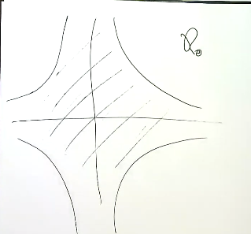

The solution: choose a convex region inside $R_0$ and apply Minkowski’s theorem, noting that this maintains the bound. For example, one can take
$$\begin{align*}
R = \left\{{ (x_1, x_2) {~\mathrel{\Big|}~}{\left\lvert {x} \right\rvert}_1 + {\left\lvert {x} \right\rvert}_2 \leq 2x^{1/2} }\right\}
,\end{align*}
which is a diamond lying inside \(R_0\) due to the AM-GM inequality.$$

Let ${ {t}_1, {t}_2, \cdots, {t}_{m}} \geq 0$, then
$$\begin{align*}
{1\over m} \sum_{i\leq m} t_i \geq \qty{ \prod_{i\leq m} t_i }^{1/m}
.\end{align*}$$

So we’ll take the region
$$\begin{align*}
R \mathrel{\vcenter{:}}=\left\{{ {\left[ {{ {x}_1, {x}_2, \cdots, {x}_{r_1 + r_2}}} \right]} \in {\mathbb{R}}^{r_1} \oplus {\mathbb{C}}^{r_2} {~\mathrel{\Big|}~}
{1\over n} \qty{ \sum_{i\leq r} {\left\lvert {x_i} \right\rvert} + 2\sum_{r_1 + 1 \leq j \leq r_1 + r_2 } {\left\lvert {x_j} \right\rvert} } \leq X^{1/n}
}\right\}
.\end{align*}
Then by AM-GM, \(R \subseteq R_0\) and \(n= r_1 + r_2\). This is still centrally symmetric, and now convex using the triangle inequality. When is \(\operatorname{vol}R > 2^n \operatorname{covol}\iota(I)\)? We’ll need to compute the volume of \(R\), which is an involved exercises in multivariable calculus. This is done in the book, and it turns out that
\begin{align*}
\operatorname{vol}(R) = 2^{r_1} \qty{\pi \over 2}^{r_2} {n^n \over n!} X
.\end{align*}
Recall that
\begin{align*}
2^n \operatorname{covol}\iota(I) = 2^n 2^{-r_2} \sqrt{{\left\lvert {{\Delta}_K} \right\rvert}}
,\end{align*}
and solving this linear equality for \(X\) yields \(X > M_K N(I)\) as defined before.$$

Now apply Minkowski’s theorem: for any $X > M_K N(I)$ there is a nonzero $\alpha\in I$, there is a nonzero $\alpha\in I$ with $\iota( \alpha)\in R$, and hence ${\left\lvert {N( \alpha)} \right\rvert} \leq X$. Note that the inequalities don’t quite match up as-is, since we can’t take $X = M_K N(I)$. Does this imply that we can find an $\alpha$ with ${\left\lvert {N( \alpha)} \right\rvert} \leq X$? The answer is yes, because we can choose $X$ with ${\left\lfloor X \right\rfloor} = {\left\lfloor M_K M(I) \right\rfloor}$. Then ${\left\lvert {N( \alpha)} \right\rvert} \leq X \implies {\left\lvert {N( \alpha)} \right\rvert} \leq {\left\lfloor X \right\rfloor} = {\left\lfloor M_K N(I) \right\rfloor}$, since the left-hand side is an integer.

## 26.2 Example: Showing Number Fields are PIDs using Dedekind-Kummer and the Minkowski Bound

Let $K = {\mathbb{Q}}( \sqrt[3]{3})$. Then $n=3$, and $r_1 = 1, r_2 = 1$ since embeddings permute the roots of $x^3-3$, which has exactly one real root. We need the discriminant, so we need an integral basis, in which case it helps to know ${\mathbb{Z}}_K$. By a homework problem, if $K = {\mathbb{Q}}(\sqrt[3]{d})$ with $d$ squarefree and $d\not\equiv \pm 1\pmod 9$, then ${\mathbb{Z}}_K$ is what you guess it’d be! So here ${\mathbb{Z}}_K = {\mathbb{Z}}[\sqrt[3]{3}]$, and thus
$$\begin{align*}
{\Delta}_K = \Delta(1, 3^{1/3}, 3^{2/3})
= {\Delta}(x^2 - 3) = -3^5
.\end{align*}$$

Thus
$$\begin{align*}
M_K = \qty{4\over \pi} {3! \over 3^3} \sqrt{3^5} \approx 4.42
,\end{align*}
and thus we know every ideal class contains a representative of norm at most 4, using that \(N(I)\) is an integer. Any such \(I\) is a product of ideals of norms \(2,3,4\). Prime ideals of norm 2 or 4 lie above the prime 2, and of norm 3 lie above 3. If we can show that every prime ideal with \(N(I) = 2,3,4\) is principal, then \(I\) will be a product of principal ideals and thus principal. Then since every class contains such an \(I\), \({ \operatorname{Cl}} ({\mathbb{Z}}_K)\) is trivial. We look at all of the primes above 2 and 3 using Dedekind-Kummer, which says the factorization of \(\left\langle{ p }\right\rangle\) mirrors the factorization of \(x^2 - 3 \pmod p\).$$

Note that if ${\mathbb{Z}}(\sqrt[3]{3}) \neq {\mathbb{Z}}_K$, there’d be some exceptional primes $p$ to worry about, but since these are equal here this is literally true for all $p$.

So we factor polynomials. First mod 2:
$$\begin{align*}
x^2 - 3 = x^3 - 1 = (x-1) (x^2 + x + 1)
,\end{align*}$$

where the second term is an irreducible quadratic with no roots in ${\mathbb{F}}_2$. This yields
$$\begin{align*}
\left\langle{ 2 }\right\rangle= \left\langle{ 2, \sqrt[3]{3} - 1 }\right\rangle \left\langle{ 2, \qty{\sqrt[3]{3} }^2 + \sqrt[3]{3} + 1 }\right\rangle
.\end{align*}
Next mod 2:
\begin{align*}
x^3 -3 = x^3
,\end{align*}
which yields
\begin{align*}
\left\langle{ 3 }\right\rangle= \left\langle{ 3, \sqrt[3]{3} }\right\rangle^3
.\end{align*}$$

Although we have explicit factorizations, but it may not obvious whether or not they’re principal. It’s easy to see that $\left\langle{ 3, 3^{1/3} }\right\rangle$ is principal since $3^{1/3} \bigm|3$ and the first generator is redundant For $\left\langle{2}\right\rangle$, it’s less clear, but
$$\begin{align*}
(3^{1/3} - 1) (3^{2/3} + 3^{1/3} + 1) = 2
,\end{align*}
and so the 2s are redundant generators in both terms. So every ideal above 2 and 3 is principal, so \(I\) is principal. Every ideal class contains such an \(I\), so \({ \operatorname{Cl}} ({\mathbb{Z}}_K) = 0\) and \({\mathbb{Z}}_K\) is a PID.$$

Asking whether or not this ring is a PID is an undergraduate-level question, but it’s not clear how one would determine this without the theory developed in this class.

Let $K = {\mathbb{Q}}(\theta)$ where $\theta$ is a root of $f(x) = x^5-x^3 + 1$. This is irreducible over ${\mathbb{Q}}$ and has one real root. Then $n=5, r_1 = 1, r_2 = 2$, but we need the discriminant to apply the Minkowski bound. If we could prove ${\mathbb{Z}}_K = {\mathbb{Z}}(\theta)$, ${\Delta}_K = {\Delta}(f)$. If it were squarefree, it’d correspond to an integral basis, so we compute
$$\begin{align*}
{\Delta}(f) = {\Delta}(1, \theta, \theta^2, \theta^3, \theta^4) =3017
,\end{align*}
using determinant formulas in the book. This is squarefree, so the power basis is an integral basis, so \({\mathbb{Z}}_K = {\mathbb{Z}}[\theta]\) and \({\Delta}_K = 3017\). Then
\begin{align*}
M_k = \qty{4\over \pi}^2 {5! \over 5^5} \sqrt{3017} \approx 3.41
.\end{align*}
So every ideal class is represented by an ideal of norm at most \(3\).$$

- Norm 1: Unit ideal and thus principal,
- Norm 2: Primes above 2
- Norm 3: Primes above 3

We’ll apply Dedekind-Kummer. First mod 2: $f(x)$ is irreducible mod 2, so $\left\langle{2}\right\rangle$ is inert and prime. So there are no ideals of norm 2, since it would have to factor as a product of primes above 2, but the only possible factor is 2 which has norm $2^5 =32$.

Mod 3: $f$ is no longer irreducible, but factors as $f=pq$ with $\deg p = 2,\deg q = 3$. So there are no ideals of norm 3, since all prime ideals above 3 would have to have norms of $3^2$ corresponding to $p$ or $3^3$ corresponding to $q$. Thus ${ \operatorname{Cl}} ({\mathbb{Z}}_K) = 0$, since every $I$ is represented by an ideal of norm 1 and hence is principal.

Next up we’ll talk about a lower bound for ${\left\lvert {{\Delta}_K} \right\rvert}$ Obviously $M_K \geq 1$, since the theorem states that every ideal class has a representative of norm at most $M_K$, and $M_K< 1$ wouldn’t make sense. Using the formula, rearranging yields a bound
$$\begin{align*}
{\left\lvert {{\Delta}_K} \right\rvert} \geq \qty{n^n \over n!}^2 \qty{\pi \over 4}^{2r_2}
.\end{align*}$$

# 27 Ch. 21: Consequences of Minkowski’s Bound (Saturday, May 22)

We were discussing a lower bound on ${\left\lvert {{\Delta}_K} \right\rvert}$. We have Minkowski’s class number bound: every ideal class has a representative of norm at most $M_K$, where
$$\begin{align*}
M_K \mathrel{\vcenter{:}}=\qty{4\over \pi}^{r_2} \qty{n! \over n^n}\sqrt{{\left\lvert {{\Delta}_K} \right\rvert}}
.\end{align*}
A consequence of the theorem is \(M_K \geq 1\), and rearranging yields a bound
\begin{align*}
{\left\lvert {{\Delta}_K} \right\rvert} \geq \qty{n^n \over n!}^2 \qty{\pi/4}^{2r)2}
.\end{align*}
What is this bound really telling us? Let’s bound the right-hand side from below. Note that \(\pi/4<1\), and since this is raised to a power, this might make things smaller. The worst case, i.e. the smallest it could be, is when \(2r_2\) is as large as possible, so using that \(r_1 + r_2 = n\) we have
\begin{align*}
{\left\lvert {{\Delta}_K} \right\rvert} \geq \qty{n^n\over n!}^2 \qty{\pi/4}^n \mathrel{\vcenter{:}}= B_n
.\end{align*}
How does \(B_n\) grow? We could use Stirling’s formula, but we’ll take a crude bound by looking at ratios:
\begin{align*}
{B_{n+1} \over B_n}
&= (1 + {1\over n})^{2n} (\pi/4)\\
&= \qty{ 1 + {2n \choose 1} {1\over n} + \cdots }(\pi/4) \\
&\geq 3\pi/4
.\end{align*}
Noting that \(B_2 = \pi^2/4\), so by induction
\begin{align*}
B_n \geq (3\pi/4)^{n-2} (\pi^2/4)
.\end{align*}$$

Some consequences:

1. ${\left\lvert {{\Delta}_K} \right\rvert} > 1$ for all number fields $K\neq {\mathbb{Q}}$.
2. ${\left\lvert {{\Delta}_K} \right\rvert}\to\infty$ as $[K:{\mathbb{Q}}]\to\infty$.

The following says why (a) is important:

$p$ ramifies in ${\mathbb{Z}}_K \iff p \bigm|{\Delta}_K$.

Omitted, see book.

So by (a), every number field $K\geq {\mathbb{Q}}$ there is at least one ramified prime $p$.

Note that if ${\left\lvert {{\Delta}_K} \right\rvert} = 1$, then $K={\mathbb{Q}}$, i.e. there is only one such number field. What about for any fixed number $n$? The next theorem says that there are only finitely many number fields occuring below a prescribed bound:

For every $X>0$, there are finitely many number fields $K$ with ${\left\lvert {{\Delta}_K} \right\rvert} \leq X$.

Since ${\left\lvert {{\Delta}_K} \right\rvert}\to\infty$ as $[K:{\mathbb{Q}}]\to\infty$, it suffices to prove this theorem with a fixed $n\mathrel{\vcenter{:}}=[K: {\mathbb{Q}}]$. We’ll make a simplifying assumption that $r_1 = n$ – this doesn’t simplify the proof so much, but rather simplifies the notation. The full proof in the book is not so different.

Define a region
$$\begin{align*}
R \mathrel{\vcenter{:}}=\left\{{{\left[ {{ {x}_1, {x}_2, \cdots, {x}_{n}}} \right]} \in {\mathbb{R}}^n {~\mathrel{\Big|}~}{\left\lvert {x_{i\leq n-1}} \right\rvert} \leq {1 \over 2},\,\, {\left\lvert {x_n} \right\rvert} \leq T }\right\} \subseteq {\mathbb{R}}^n
,\end{align*}
where we’ll specify \(T\) in a moment.$$

Note that

- $R$ is centrally symmetric
- $R$ is convex, by the triangle inequality,
- The volume is easily computable: $\operatorname{vol}R = 1\cdot 1\cdot \ldots \cdot 1 \cdot 2T = 2T$.

Choose $T = 2^n \sqrt{X}$. Suppose $K$ is totally real with ${\left\lvert { {\Delta}_K } \right\rvert} \leq X$. Recall that
$$\begin{align*}
\operatorname{covol}\iota {\mathbb{Z}}_K = 2^{r_2} \sqrt{{\left\lvert {{\Delta}_K} \right\rvert}}
\leq \sqrt{X}
.\end{align*}$$

Then
$$\begin{align*}
\operatorname{vol}R = 2^{n+1 } \sqrt{X} > 2^n \operatorname{covol}\iota {\mathbb{Z}}_K
,\end{align*}
so Minkowski’s theorem can be applied: there is a nonzero \(\alpha\in {\mathbb{Z}}_K\) with \(\iota( \alpha) \in R\). Then \({\left\lvert {\sigma_i( \alpha)} \right\rvert} \leq 1/2\) for \(i\leq n-1\) and \({\left\lvert { \sigma_n ( \alpha)} \right\rvert} \leq T\). The claim is that there are only finitely many such \(\alpha\), since it was a root of a polynomial in a finite set \(P_{n, T}\). The claim is now that \(K = {\mathbb{Q}}( \alpha)\), so this \(\alpha\) uniquely determines \(K\). Since there were finitely many \(\alpha\), there can only be finitely many such \(K\).$$

The claim is that the size of $\sigma_n( \alpha)$ has to be big, say at least 1. We have control over the product, since
$$\begin{align*}
1\leq {\left\lvert {N \alpha} \right\rvert}
= \prod {\left\lvert { \sigma_i( \alpha)} \right\rvert}
\leq {1\over 2^{n-1}} {\left\lvert { \sigma_n( \alpha)} \right\rvert}
,\end{align*}
since the first \(n-1\) terms contribute at most \(1/2\) each. So \({\left\lvert {\sigma_n( \alpha)} \right\rvert} \geq 2^{n-1} \geq 1\). Suppose now that \({\mathbb{Q}}(\alpha) < K\) is a proper subfield, so \([K : {\mathbb{Q}}( \alpha)] = d > 1\). Then every embedding \({\mathbb{Q}}(\alpha) \hookrightarrow{\mathbb{C}}\) extends to \(d\) embeddings \(K\hookrightarrow{\mathbb{C}}\), but this means that for any element \(x \in {\mathbb{Q}}(\alpha)\), the images \(\sigma_1(x),\cdots, \sigma_n(x)\) would have the same element repeated \(d\) times. But we know that \(\sigma_n( \alpha)\) is different from all of the other \(\sigma_i( \alpha)\), so this is a contradiction.$$

Idea of proof: making sure some image of $\alpha$ under one embedding is different than all of the other images.

Some remarks on modern research! Let $N_n(X)$ be the set of number fields of degree $n$ where ${\left\lvert {{\Delta}_K} \right\rvert} \leq X$.

For each fixed $n$,
$$\begin{align*}
\lim_{X\to \infty} {N_n(X) \over X} = \delta_n > 0
,\end{align*}
where \(\delta_n\) is some particular constant.$$

Some known results:

- $n=2$: known to Gauss, since this is more or less equivalent to counting squarefree numbers.
- $n=3$: much harder, Davenport-Heilbronn.
- $n=4, 5$: Bhargava, part of what resulted in his 2014 Fields medal.

One could restrict this problem, e.g. by prescribing a particular Galois group. See Mahler’s conjecture.

# 28 Chapter XYZ: Relative Extensions, Galois Theory, Prime Splitting

Up until now: we’ve compared extensions over ${\mathbb{Q}}$:

[figure not shown]

> Link to Diagram

We’ll next talk about extensions between number fields:

[figure not shown]

> Link to Diagram

We can ask the same sorts of questions about prime ideals factoring. Note that if $I = \prod P_i^{e_i}$ with each $P_i \in \operatorname{Spec}{\mathbb{Z}}_K$ , then extending to ${\mathbb{Z}}_L$ yields
$$\begin{align*}
I{\mathbb{Z}}_L = \prod (P_i {\mathbb{Z}}_L)^{e_i}
.\end{align*}
So we want to understand the following: given a prime ideal \(P\) of \({\mathbb{Z}}_K\), how does \(P{\mathbb{Z}}_L\) factor?$$

Let $K\leq L$ be number fields, and suppose $Q\in \operatorname{Spec}{\mathbb{Z}}_L, P\in \operatorname{Spec}{\mathbb{Z}}_K$. Then we say $Q$ **lies above** $P$ if $Q \supseteq P$, or equivalently $Q \bigm|P{\mathbb{Z}}_L$.

Every nonzero $Q\in \operatorname{Spec}{\mathbb{Z}}_L$ lies above a unique nonzero $P \in \operatorname{Spec}{\mathbb{Z}}_K$.

Consider $P \mathrel{\vcenter{:}}= Q \cap{\mathbb{Z}}_K \in \operatorname{Spec}{\mathbb{Z}}_K$. This is nonzero because taking the norm of any element of $Q$ yields a nonzero integer still in the ideal. Then $Q$ lies above $P$ by definition. Why is this unique? Suppose $Q$ lies about $P'$, we’ll show $P = P'$. Since $Q$ lies above $P'$, $Q\supseteq P'$. But $P'{~\trianglelefteq~}{\mathbb{Z}}_K$, so $Q\cap{\mathbb{Z}}_K \supseteq P'$, so $P \supseteq P'$. We know $P'$ is maximal, since ${\mathbb{Z}}_K/P'$ is a finite domain and thus a field, so $P = P'$.

Let $P\in \operatorname{Spec}{\mathbb{Z}}_K$, then write
$$\begin{align*}
P{\mathbb{Z}}_L = \prod Q_i^{e_i}
\end{align*}
with \(Q_i \in \operatorname{Spec}{\mathbb{Z}}_L\). Then the \(Q_i\) are the prime ideals of \({\mathbb{Z}}_L\) above \(P\). The exponent \(e_i\) is called the ramification degree, usually denoted \(e(Q_i/P)\). We have the following picture:$$

[figure not shown]

> Link to Diagram

The inclusion ${\mathbb{Z}}_K \hookrightarrow{\mathbb{Z}}_L$ induces a ring morphism ${\mathbb{Z}}_K \to {\mathbb{Z}}_L/Q$, where the kernel is ${\mathbb{Z}}_K \cap Q = P$. Thus there is an injection ${\mathbb{Z}}_K/P \hookrightarrow{\mathbb{Z}}_L/Q$, which is an inclusion of finite fields. So we’ll define
$$\begin{align*}
f(Q/P) \mathrel{\vcenter{:}}=[{\mathbb{Z}}_L/Q : {\mathbb{Z}}_K/P]
\end{align*}
to be the residue degree of \(Q/P\). Note that
\begin{align*}
\# {\mathbb{Z}}_L/{\mathbb{Q}}= \qty{\# {\mathbb{Z}}_K/P}^{f(Q/P)}
\quad\text{i.e.}\quad
N_L(Q) = N_K(P)^{f(Q/P)}
.\end{align*}$$

If $P \in \operatorname{Spec}{\mathbb{Z}}_K$ is nonzero with $P{\mathbb{Z}}_L = \prod Q_i^{e_i}$, then
$$\begin{align*}
\sum_i e(Q_i/P) f(Q_i/P) = [L: K]
.\end{align*}$$

If $I\in \operatorname{Spec}{\mathbb{Z}}_K$ is nonzero, then extend to $L$ to get $I{\mathbb{Z}}_L$. Then
$$\begin{align*}
N_L (I{\mathbb{Z}}_L) = \qty{ N_K(I)}^{[L : K]}
.\end{align*}$$

Omitted. Idea of why it’s true: the norm of an ideal is supposed to be a “product of conjugates,” although naive conjugates of an ideal might not remain an ideal in the field one starts with. So interpret norms as products of images under all embeddings into ${\mathbb{C}}$. But then just interpret $[L: K]$ is the number of lifts of embeddings $K\hookrightarrow{\mathbb{C}}$ to $L\hookrightarrow{\mathbb{C}}$.

Take norms in $L$, then
$$\begin{align*}
N( P{\mathbb{Z}}_L)
= \prod N(Q_i)^{e_i} \\
= N_K(P)^{e_1 \sum f(Q_i/P)}
.\end{align*}
On the other hand, the left-hand side is \(N_K(P)^{[L: K]}\), so the exponents must be equal.$$

What are the specific prime ideals involved in the factorization, i.e. is there a generalization of Dedekind-Kummer here?

Write $L = K(\theta)$ for some $\theta \in L \cap\mkern 1.5mu\overline{\mkern-1.5mu{\mathbb{Z}}\mkern-1.5mu}\mkern 1.5mu= {\mathbb{Z}}_L$. Let $m(x)$ be the minimal polynomial of $\theta$ over $K$, so $m\in {\mathbb{Z}}_K[x]$. Let $P\in \operatorname{Spec}{\mathbb{Z}}_K$ lying above $p\in \operatorname{Spec}{\mathbb{Z}}$. Then as long as $p% \mathrel{\mkern.5mu % small adjustment % superimpose \nmid to \big| \ooalign{\hidewidth$\big|$\hidewidth\cr$\nmid$\cr}% }% [{\mathbb{Z}}_L: {\mathbb{Z}}_K[\theta]]$, then the factorization of $P{\mathbb{Z}}_L$ mirrors the factorization of $m$ over the residue field ${\mathbb{Z}}_K/P$.

Omitted, see “Number Rings” by Marcus. Paul strongly recommends!

# 29 Ch. XYZ: April 6

## 29.1 Multiplicativity in Towers

An important topic not in the book: relative extensions of number fields, vs absolute extensions over ${\mathbb{Q}}$.

[figure not shown]

> Link to Diagram

Note that if $Q\supseteq P$, then $Q$ will divide the extension of $P$ to ${\mathbb{Z}}_L$, if $Q$ will show up in the prime factorization of $P{\mathbb{Z}}_L$. We defined $e(Q/P)$ to be the exponent of $Q$ in the factorization of $P{\mathbb{Z}}_L$, and $f(Q/P)$ to be the degree of the field extension ${\mathbb{Z}}_L/Q$ over ${\mathbb{Z}}_K/P$.

Note that “lying above” is transitive, and the following situation makes sense:

[figure not shown]

> Link to Diagram

How are the various $e$ and $f$ related? It turns out they work similarly to degrees of field extensions:

$$\begin{align*}
e(P''/P) &= e(P''/P') \cdot e(P'/P) \\
f(P''/P) &= f(P''/P') \cdot f(P'/P)
.\end{align*}$$

Note that $f$ is the degree of a field extension where we take ${\mathbb{Z}}_K/P \hookrightarrow{\mathbb{Z}}_L$ and consider the induced quotient map to ${\mathbb{Z}}_L/Q$. By composing inclusions we have a commutative diagram:

[figure not shown]

> Link to Diagram

So for $f$, this reduces to the multiplicativity of degrees in towers of field extensions.

For $e$, write $P{\mathbb{Z}}_L = P'^{e(P'/P)} I$ where $I\in \operatorname{Id}({\mathbb{Z}}_L)$ is nonzero and $P'% \mathrel{\mkern.5mu % small adjustment % superimpose \nmid to \big| \ooalign{\hidewidth$\big|$\hidewidth\cr$\nmid$\cr}% }% I$. Similarly we can write $P' {\mathbb{Z}}_< = P''^{e(P'/P')} J$ where $J\in \operatorname{Id}({\mathbb{Z}}_L)$ and $P''% \mathrel{\mkern.5mu % small adjustment % superimpose \nmid to \big| \ooalign{\hidewidth$\big|$\hidewidth\cr$\nmid$\cr}% }% J$. Using general facts about ideal extensions and substituting yields
$$\begin{align*}
P{\mathbb{Z}}_M
&= (P{\mathbb{Z}}_L){\mathbb{Z}}_M \\
&= (P'{\mathbb{Z}}_M)^{e(P'/P)} I{\mathbb{Z}}_M \\
&= P''^{e(P'/P) e(P'/P')} J^{e(P'/P)} (I{\mathbb{Z}}_M) \\
.\end{align*}$$

We know that $P''% \mathrel{\mkern.5mu % small adjustment % superimpose \nmid to \big| \ooalign{\hidewidth$\big|$\hidewidth\cr$\nmid$\cr}% }% J$, so it doesn’t divide any power of $J$ either. We can check that $P''% \mathrel{\mkern.5mu % small adjustment % superimpose \nmid to \big| \ooalign{\hidewidth$\big|$\hidewidth\cr$\nmid$\cr}% }% I{\mathbb{Z}}_M$: otherwise, if it did then $P''\supseteq I{\mathbb{Z}}_M$ and
$$\begin{align*}
P'' \cap{\mathbb{Z}}_L \supseteq (I{\mathbb{Z}}_M) \cap{\mathbb{Z}}_L \supset I
\end{align*}
by intersecting both sides with \({\mathbb{Z}}_L\). But we know \(P'' \cap{\mathbb{Z}}_L = P'\) since \(P''\) was above \(P'\), and \(P'% \mathrel{\mkern.5mu % small adjustment % superimpose \nmid to \big| \ooalign{\hidewidth$\big|$\hidewidth\cr$\nmid$\cr}% }% I\) and thus \(P'\not\supseteq I\).$$

Suppose $L/K$ is an extension of number fields and say $P\supseteq {\mathbb{Z}}_K$ is a nonzero prime ideal. Then $P$ **splits completely** in $L$ (or ${\mathbb{Z}}_L$) if $e(G/P) = f(G/P) = 1$ for all $G$ above $P$ in ${\mathbb{Z}}_L$. Equivalently, there is a factorization $P{\mathbb{Z}}_L = \prod_{i\leq n} Q_i$ with the $Q_i$ distinct and $n \mathrel{\vcenter{:}}=[L: K]$.

Let $M/L/K$ be a tower of number fields and $P\in \operatorname{Spec}{\mathbb{Z}}_K$. Then if $P$ splits completely in $M$, it splits completely in $L$.

Splitting completely in an extension implies splitting completely in every intermediate extension.

Suppose $P$ splits completely in $M$, we then want to show that for any $P'$ in ${\mathbb{Z}}_L$ above $P$, then $e=f=1$. We know $P'$ has some prime factor, so choose any $P''$ in ${\mathbb{Z}}_M$ above $P'$:

[figure not shown]

> Link to Diagram

Since $P''$ is above $P$ and $e(P''/P) = f(P''/P) =1$, we can use multiplicativity in towers:
$$\begin{align*}
e(P'/P) \bigm|e(P''/P) = 1 &\implies e(P'/P) = 1 \\
f(P'/P) \bigm|f(P''/P) = 1 &\implies f(P'/P) = 1 \\
.\end{align*}$$

If $L/K$ is an extension of number fields and $P\in \operatorname{Spec}{\mathbb{Z}}_K$ is nonzero, then $P$ **ramifies** in $L$ (or ${\mathbb{Z}}_L$) if $e(Q/P)>1$ for some $Q\in \operatorname{Spec}{\mathbb{Z}}_L$ above $P$.

For $M/L/K$ a tower of number fields and $P\in \operatorname{Spec}{\mathbb{Z}}_K$ is nonzero and unramified in $M$, then $P$ is unramified in $L$.

Same as the last proof.

## 29.2 Galois Theory and Prime Decomposition

This will lead into defining the Frobenius element and the fundamental theorem of algebraic number theory: Chebotarev Density. Some setup/notation:

- $L/K$ will be a Galois extension of number of fields
- $P \in \operatorname{Spec}{\mathbb{Z}}_K, Q\in \operatorname{Spec}{\mathbb{Z}}_L$ will be nonzero prime ideals. We may or may not require $Q$ to lie above $P$.
- Any $\sigma \in G(L/K)$ is an automorphism of $L$ fixing $K$, which restricts to an automorphism of ${\mathbb{Z}}_L$ since it preserves algebraic integers.
  - It also preserves prime ideals.
- Suppose $Q$ lies above $P$, then $P{\mathbb{Z}}_L = Q^{e(Q/p)} \cdots$. $\sigma$ fixes $K$ pointwise, so applying it to both sides yields $P{\mathbb{Z}}_L = \sigma(Q)^{e(Q/P)}\cdots$ where $\sigma(Q)$ shows up with the exact same power since it preserves distinctness of ideals.
  - In particular, $\sigma(G)$ lies above $P$, so $G(L/K)$ acts on the set of primes above $P$, and it turns out (very importantly) to be transitive.

The action of $G(L/K)$ on primes above $P$ is transitive.

Let $Q_1, Q_2$ be primes above $P$ and suppose toward a contradiction that ${\mathrm{Orb}}(Q_1)$ does not contain $Q_2$. We may choose $\alpha\in {\mathbb{Z}}_L$ such that

- $\alpha \equiv 0 \pmod Q_2$
- $\alpha \equiv 1 \pmod Q$ for all $Q$ of the form $Q = \sigma(Q_1)$, noting that none are $Q_2$

This system can be solved by the CRT, since the $Q_i$ are pairwise comaximal, since nonzero primes of a number ring are maximal. These congruences say $\alpha\in Q_2$ but not any other $Q$, since $0\equiv 1$ only in the unit ideal. Define $\beta = \prod_{\sigma \in G(L/K)} \sigma( \alpha) \in {\mathbb{Z}}_K$, and observe that $\beta\not\in Q_1$. If it were in $Q_1$, one $\sigma(\alpha) \in Q_1$ for some $\sigma \in G(L/K)$ which would force $\alpha = \sigma \sigma^{-1}( \alpha) \in \sigma^{-1}(Q_1)$, which contradicts the choice of $\alpha$ since $\sigma^{-1}(Q_1)$ is one of the $Q$s appearing in the second congruence. On the other hand we have $\beta\in Q_2$ since the identity is an element of $G(L/K)$ and $\alpha\in Q_2$ and $\beta$ is a multiple of $\alpha$. We know $\beta\in {\mathbb{Z}}_K$, so $\beta \in Q_2 \cap{\mathbb{Z}}_K = P$. But this is fishy because $Q_1, Q_2$ both lie above $P$ and both must contain $P$:

[figure not shown]

> [Link to Diagram](https://q.uiver.app/?q=WzAsMyxbMSwyLCJQIl0sWzAsMCwiUV8xIl0sWzIsMCwiUV8yIl0sWzEsMCwiIiwwLHsic3R5bGUiOnsiaGVhZCI6eyJuYW1lIjoibm9uZSJ9fX1dLFsyLDAsIiIsMix7InN0eWxlIjp7ImhlYWQiOnsibmFtZSI6Im5vbmUifX19XV0=)

Since $\beta$ is in every ideal above $P$, in particular $\beta \in Q_1$ since $Q_1 \supseteq P$, and this is a contradiction.

If $Q, Q'$ both lie above $P$, then $e(Q/P) = e(Q'/P)$ and $f(Q/P) = f(Q'/P)$.

Pick $\sigma \in G(L/K)$ with $\sigma(Q) = Q'$. Factor $P{\mathbb{Z}}_L = Q^{e(Q/P)} J$ where $J$ is a product of primes not equal to $Q$. Applying $\sigma$ yields $P{\mathbb{Z}}_L = Q'^{e(Q/P)} J'$ where $J'$ is a product of primes not equal to $Q'$. This factors $P{\mathbb{Z}}_L$ into primes, and by uniqueness of prime factorization this exponent has to be $e(Q'/P)$ by definition.

For the $f$s, note that $\sigma$ induces a ring morphism between the residue fields:
$$\begin{align*}
\mkern 1.5mu\overline{\mkern-1.5mu\sigma\mkern-1.5mu}\mkern 1.5mu: {\mathbb{Z}}_K/Q &\to {\mathbb{Z}}_L/Q' \\
\alpha \pmod Q &\mapsto \sigma(\alpha) \pmod Q'
.\end{align*}
This is well-defined since \(\sigma(Q) = Q'\), and is an isomorphism since the inverse comes from \(\sigma ^{-1}\). This will imply that the \(f\)s are the same: we’re looking at the degree of these extensions over \({\mathbb{Z}}_K/P\). An element of \({\mathbb{Z}}_L/Q\) also belonging to \({\mathbb{Z}}_K/P\) (as a subfield) has the form \(\alpha \pmod Q\) where \(\alpha\in {\mathbb{Z}}_K\), and under \(\sigma\) this is sent to \(\sigma(\alpha)\pmod Q' = \alpha \pmod Q'\), which is an element of the copy of \({\mathbb{Z}}_K/P\hookrightarrow{\mathbb{Z}}_L/Q'\). So \(\sigma\) identifies the copies of \({\mathbb{Z}}_K/P\) in either side, and
\begin{align*}
[{\mathbb{Z}}_L/Q : {\mathbb{Z}}_K/P] = [{\mathbb{Z}}_L/Q: {\mathbb{Z}}_K/P]
.\end{align*}$$

Let $L/K$ be a Galois extension of number fields and $P\in \operatorname{Spec}{\mathbb{Z}}_K$ be nonzero. Let $e,f$ be the common $e, f$ for all $Q$ above $P$, and let $g$ be the number of distinct $Q$ above $P$. Then
$$\begin{align*}
efg = n \mathrel{\vcenter{:}}=[L:K]
.\end{align*}$$

Using the previous efg theorem, $\sum_{i=1}^g e_i f_i = n$, but by the previous proposition, all of the $e_i$ are the same and all of the $f_i$ are the same.

Let $L = {\mathbb{Q}}(\zeta_5)$ over $K= {\mathbb{Q}}$, which is Galois with $G(L/K) \cong ({\mathbb{Z}}/5)^{\times}\cong {\mathbb{Z}}_4$. We know ${\mathbb{Z}}_L = {\mathbb{Z}}[\zeta_5]$, which actually happens for any $n$, and $\min_{\zeta_5}(x) = x^4 + x^3 + x^2 + x + 1$. Since ${\mathbb{Z}}_L$ is a monogenic, we can apply Dedekind-Kummer.

- Factoring $2{\mathbb{Z}}_L = P$ yields a single factor, so $g=1$. Since $e$ is the common exponent, $e=1$, so $f=4$. If you factor $\min_{\zeta_5}$ mod 2, in order to get a single prime D-K says this must be irreducible and $f_i$ are the degrees of the irreducible factors.
- $19{\mathbb{Z}}_L = P_1 P_2$, so $g=2, e=1$, and so $f=2$.
- $11{\mathbb{Z}}_L = P_1 P_2 P_3 P_4$ yields $g=4, e=1, f=1$.
- $5{\mathbb{Z}}_L = P_1^4$ so $g=1,e=4,f=1$.

Can the combination $(e,f,g) = (2,2,1)$ occur? This would require a prime factoring as $P^2$, but the answer is know. In fact $e>1$ only happens for $5$ since this corresponds (for all applicable primes $p$, which is all primes since ${\mathbb{Z}}_L$ is monogenic here) to the polynomial having a repeated factor mod $p$. This would require ${\Delta}(\min_{\zeta_5}(x)) \equiv 0 \pmod p$, but you can show that $5$ is the only prime that divides this discriminant. So $5$ is the only prime that could ramify, so $e=2$ never happens.

In general, for cyclotomic extensions, $p$ is always totally ramified and $e=p-1$.

## 29.3 Decomposition, Inertia, Frobenius

Let $L/K$ be a Galois extension of number fields and let $Q \in \operatorname{Spec}{\mathbb{Z}}_L$ be nonzero. Then $Q$ lies above a unique prime $P \in \operatorname{Spec}{\mathbb{Z}}_K$, where $P = Q \cap{\mathbb{Z}}_K$. Define the **decomposition group of $Q$** is defined as
$$\begin{align*}
D(Q) = D(Q/P) = \left\{{ \sigma \in G(L/K) {~\mathrel{\Big|}~}\sigma(Q) = Q}\right\}
.\end{align*}$$

Better notation: define ${\mathbb{F}}_Q \mathrel{\vcenter{:}}={\mathbb{Z}}_L/Q$ and ${\mathbb{F}}_P = {\mathbb{Z}}_K/P$, so ${\mathbb{F}}_P \subseteq {\mathbb{F}}_Q$.

We know that the Galois group will take $Q$ to some prime above $P$, these are the ones that take $Q$ to itself. These are the automorphisms that make sense “modulo $Q$”: there is a group morphism
$$\begin{align*}
{ \text{red} }_{Q/P}: D(G/P) &\to G({\mathbb{F}}_Q/{\mathbb{F}}_P) \\
\sigma &\mapsto \mkern 1.5mu\overline{\mkern-1.5mu\sigma \mkern-1.5mu}\mkern 1.5mu
.\end{align*}
where we reduce \(\sigma\) mod \(Q\), so \(\mkern 1.5mu\overline{\mkern-1.5mu\sigma\mkern-1.5mu}\mkern 1.5mu(\alpha \pmod Q) \mathrel{\vcenter{:}}=\sigma(\alpha) \pmod Q\). One can check$$

- For $\sigma \in D(Q/P)$, $\mkern 1.5mu\overline{\mkern-1.5mu\sigma\mkern-1.5mu}\mkern 1.5mu$ is a well-defined automorphism of ${\mathbb{F}}_Q$ fixing ${\mathbb{F}}_P$, since the elements in ${\mathbb{F}}_P$ are of the form $\alpha \pmod Q$ where $\alpha\in {\mathbb{Z}}_K$ and $\sigma$ fixes $K$. This crucially uses that $\sigma$ fixes $Q$, otherwise it won’t be well-defined.
- ${ \text{red} }_{Q/P}$ defines a group morphism.

We’ll see later that this is in fact a surjective morphism. So all automorphisms in the Galois group $G({\mathbb{F}}_Q/{\mathbb{F}}_P)$ are reductions mod $Q$ of automorphisms in the decomposition group, which are the only ones that make sense to reduce mod $Q$ anyway!

# 30 Ch. XYZ: Galois Theory and Prime Decomposition (April 13)

Two recommended resources:

- Samuel, Algebraic Theory of Numbers (Dover)
- Matt Baker’s [online notes on Algebraic number theory](https://people.math.gatech.edu/~mbaker/pdf/ANTBook.pdf).

Setup:

- $L/K$ a Galois extension of number fields.
- $P \in \operatorname{mSpec}K$
- $Q\in \operatorname{mSpec}L$

We saw that $G(L/K)$ acts on the prime ideals above $P$, making all of the $e,f$ values the same, and thus the decomposition into prime ideals in this type of extension is simpler than in a general extension. We’ll look at decomposition and inertia groups today.

Recall that if $Q$ lies above $P$, then the **decomposition group** $D(Q/P)$ is the set of $\sigma\in G(L/K)$ such that $\sigma(Q) = Q$. Note that $P$ is redundant in this notation, since $Q \cap{\mathbb{Z}}_K = P$. Also recall that ${\mathbb{F}}_Q \mathrel{\vcenter{:}}={\mathbb{Z}}_L/Q$ is the residue field associated to $Q$ and ${\mathbb{Z}}_P \mathrel{\vcenter{:}}={\mathbb{Z}}_L/P$ and we view ${\mathbb{F}}_P \subseteq {\mathbb{F}}_Q$. Such an extension of finite fields is always Galois, and the Galois groups turn out to be related to the decomposition groups. For $\sigma \in D(Q/P)$ we defined $\mkern 1.5mu\overline{\mkern-1.5mu\sigma\mkern-1.5mu}\mkern 1.5mu: {\mathbb{F}}_Q \to {\mathbb{F}}_Q$ where $\alpha \pmod Q \mapsto \sigma(\alpha) \pmod Q$. It’s easy to check this is

- Well-defined, precisely by the definition of $D(Q/P)$,
- An automorphism of ${\mathbb{F}}_Q$: it must be surjective since everything in ${\mathbb{Z}}_L$ is in the image of $\sigma$ since $\sigma$ was an automorphism of ${\mathbb{Z}}_L$ to begin with. But then it’s a surjective morphism from a finite field to itself, hence an automorphism.
- $\sigma$ fixed ${\mathbb{F}}_P$ pointwise Now consider applying $\sigma$ to an element of ${\mathbb{F}}_P$, which are of the form $\alpha \pmod Q$ where $\alpha$ comes from ${\mathbb{Z}}_K$. But $\sigma$ fixed ${\mathbb{Z}}_K$ pointwise, so $\sigma$ fixed ${\mathbb{F}}_P$ pointwise.

So each $\sigma\in D(Q/P)$ yields a $\mkern 1.5mu\overline{\mkern-1.5mu\sigma \mkern-1.5mu}\mkern 1.5mu\in G({\mathbb{F}}_Q/{\mathbb{F}}_P)$ and we get a group morphism
$$\begin{align*}
{ \text{red} }_{Q/P}: D(Q/P) &&\to G({\mathbb{F}}_Q/{\mathbb{F}}_P) \\
\sigma &\mapsto \mkern 1.5mu\overline{\mkern-1.5mu\sigma\mkern-1.5mu}\mkern 1.5mu
.\end{align*}
The following is the deeper and more important fact about this morphism, which requires a technical proof:$$

${ \text{red} }_{Q/P}$ is surjective.

We can assume ${\mathbb{F}}_P$ is a proper subfield of ${\mathbb{F}}_Q$, since the result follows immediately otherwise. By the primitive element theorem, since $|FF_Q/{\mathbb{F}}_P$ is separable we can write ${\mathbb{F}}_Q = {\mathbb{F}}_P(\mkern 1.5mu\overline{\mkern-1.5mu\alpha\mkern-1.5mu}\mkern 1.5mu)$ where $\alpha\in {\mathbb{Z}}_L$ and $\mkern 1.5mu\overline{\mkern-1.5mu{-}\mkern-1.5mu}\mkern 1.5mu$ denotes reducing mod $Q$. Note $\alpha\not\in Q$, since this would mean $\mkern 1.5mu\overline{\mkern-1.5mu\alpha \mkern-1.5mu}\mkern 1.5mu= 0$ and thus ${\mathbb{F}}_Q = {\mathbb{F}}_P$. On the other hand, we can assume $\alpha\in Q'$ for all other $Q'\neq Q$ above $P$. Why? Sketch: the equation ${\mathbb{F}}_Q = {\mathbb{F}}_P(\mkern 1.5mu\overline{\mkern-1.5mu\alpha\mkern-1.5mu}\mkern 1.5mu)$ only depends on $\alpha\pmod Q$, so if $\alpha$ is not in some $Q'$, just adjust $\alpha$ modulo $Q'$ without affecting its class mod $Q$ to get a new $\alpha$ in $Q'$. So if not, replace $\alpha$ with $\alpha'$ satisfying
$$\begin{align*}
\alpha' \cong \alpha \pmod Q \\
\alpha'\cong 0 \pmod Q' && \forall Q'\neq Q \text{ above }P
.\end{align*}$$

Look at the minimal polynomial $\mkern 1.5mu\overline{\mkern-1.5mum\mkern-1.5mu}\mkern 1.5mu(x)$ of $\mkern 1.5mu\overline{\mkern-1.5mu\alpha\mkern-1.5mu}\mkern 1.5mu$ over ${\mathbb{F}}_P$, some monic polynomial in ${\mathbb{F}}_P[x]$, where ${\mathbb{F}}_P$ is the reduction mod $P$ of elements in ${\mathbb{Z}}_K$. So we can think of $\mkern 1.5mu\overline{\mkern-1.5mum\mkern-1.5mu}\mkern 1.5mu(x)$ as some $m(x) \in {\mathbb{Z}}_K[x]$ whose coefficients have been reduced mod $Q$. We’ll show that for each root $r$ of $\mkern 1.5mu\overline{\mkern-1.5mum\mkern-1.5mu}\mkern 1.5mu(x)$ in ${\mathbb{F}}_Q$, there is some $\sigma\in D(Q/P)$ such that $\mkern 1.5mu\overline{\mkern-1.5mu\sigma\mkern-1.5mu}\mkern 1.5mu(\mkern 1.5mu\overline{\mkern-1.5mu\alpha\mkern-1.5mu}\mkern 1.5mu) = r$ This is enough, since any automorphism of ${\mathbb{F}}_Q$ fixing ${\mathbb{F}}_P$ is determined by the image of $\mkern 1.5mu\overline{\mkern-1.5mu\alpha\mkern-1.5mu}\mkern 1.5mu$, which has to go to some other root of $\mkern 1.5mu\overline{\mkern-1.5mum\mkern-1.5mu}\mkern 1.5mu (x)$. If we can show this statement, this means that $\mkern 1.5mu\overline{\mkern-1.5mu\sigma\mkern-1.5mu}\mkern 1.5mu$ has to hit every automorphism in $G({\mathbb{F}}_Q/{\mathbb{F}}_P)$.

Define $g(x) = \prod_{\sigma\in G(L/K)} (x- \sigma( \alpha))$. Where does $g$ live? $\alpha$ came from $L$, so $\sigma( \alpha) \in L$, and multiplying over all $\sigma$ puts the coefficients in $K$. Even better, since $\alpha\in {\mathbb{Z}}_L$ is algebraic, this will have ${\mathbb{Z}}_K$ coefficients, so $g\in {\mathbb{Z}}_K[x]$. Now reduce mod $Q$ to get $\mkern 1.5mu\overline{\mkern-1.5mug\mkern-1.5mu}\mkern 1.5mu(x) \in {\mathbb{F}}_P[X]$, and moreover $\mkern 1.5mu\overline{\mkern-1.5mug\mkern-1.5mu}\mkern 1.5mu(\mkern 1.5mu\overline{\mkern-1.5mu\alpha\mkern-1.5mu}\mkern 1.5mu) = \mkern 1.5mu\overline{\mkern-1.5mug(\alpha)\mkern-1.5mu}\mkern 1.5mu = 0$ in ${\mathbb{F}}_Q$, since $g(\alpha) = 0$ by definition since one $\sigma$ in the product is the identity. Thus we know $\mkern 1.5mu\overline{\mkern-1.5mum\mkern-1.5mu}\mkern 1.5mu(x) \bigm|\mkern 1.5mu\overline{\mkern-1.5mug\mkern-1.5mu}\mkern 1.5mu(x)$ in ${\mathbb{F}}_P[x]$. Notice that in ${\mathbb{F}}_Q[x]$, if we take $g$ and reduce mod $Q$ we get
$$\begin{align*}
\mkern 1.5mu\overline{\mkern-1.5mug\mkern-1.5mu}\mkern 1.5mu(x) = \prod_{\sigma \in G(L/K)} (x - \mkern 1.5mu\overline{\mkern-1.5mu\sigma(\alpha)\mkern-1.5mu}\mkern 1.5mu )
.\end{align*}
Since \(\mkern 1.5mu\overline{\mkern-1.5mum\mkern-1.5mu}\mkern 1.5mu(x)\) divides \(\mkern 1.5mu\overline{\mkern-1.5mug\mkern-1.5mu}\mkern 1.5mu(x)\), every root of \(\mkern 1.5mu\overline{\mkern-1.5mum\mkern-1.5mu}\mkern 1.5mu\) has the form \(\mkern 1.5mu\overline{\mkern-1.5mu\sigma( \alpha)\mkern-1.5mu}\mkern 1.5mu\) for some \(\sigma\in G(L/K)\). We want this to be \(\mkern 1.5mu\overline{\mkern-1.5mu\sigma\mkern-1.5mu}\mkern 1.5mu(\mkern 1.5mu\overline{\mkern-1.5mu\alpha\mkern-1.5mu}\mkern 1.5mu)\) instead to conclude the proof, so take a root of \(\mkern 1.5mu\overline{\mkern-1.5mum\mkern-1.5mu}\mkern 1.5mu\) in \({\mathbb{F}}_Q\) and write it as \(\mkern 1.5mu\overline{\mkern-1.5mu\sigma(\alpha)\mkern-1.5mu}\mkern 1.5mu\) with \(\sigma\in G(L/K)$$

$\sigma \in D(G/P)$ has to be in the decomposition group.

If this is true, we’re done since $\mkern 1.5mu\overline{\mkern-1.5mu\sigma( \alpha)\mkern-1.5mu}\mkern 1.5mu = \mkern 1.5mu\overline{\mkern-1.5mu\sigma \mkern-1.5mu}\mkern 1.5mu(\mkern 1.5mu\overline{\mkern-1.5mu\alpha\mkern-1.5mu}\mkern 1.5mu)$.

Suppose toward a contradiction that $\sigma\not\in D(G/P)$, so neither $\sigma$ nor $\sigma^{-1}$ fixes $Q$, so $\sigma^{-1}(Q) \neq Q$. By choice of $\alpha$, we have $\alpha \in Q' \mathrel{\vcenter{:}}=\sigma^{-1}(Q)$, so $\sigma(\alpha)\in Q$. Then $\mkern 1.5mu\overline{\mkern-1.5mu\sigma(\alpha)\mkern-1.5mu}\mkern 1.5mu = 0$, but $0$ is not a root of $\mkern 1.5mu\overline{\mkern-1.5mum\mkern-1.5mu}\mkern 1.5mu(x)$ since it is irreducible where $\mkern 1.5mu\overline{\mkern-1.5mum\mkern-1.5mu}\mkern 1.5mu(x) \neq x$ since $[{\mathbb{F}}_Q: {\mathbb{F}}_P] \geq 2$ and thus $\deg \mkern 1.5mu\overline{\mkern-1.5mum\mkern-1.5mu}\mkern 1.5mu(x) \geq 2$.

By the first isomorphism theorem, we have
$$\begin{align*}
G({\mathbb{F}}_Q/{\mathbb{F}}_P) \cong D(Q/P) / \ker { \text{red} }_{Q/P}
.\end{align*}
, where we call the kernel the inertia group:
\begin{align*}
\ker { \text{red} }_{Q/P} = I(Q/P) \mathrel{\vcenter{:}}=\left\{{ \sigma \in D(Q/P) {~\mathrel{\Big|}~}\mkern 1.5mu\overline{\mkern-1.5mu\sigma \mkern-1.5mu}\mkern 1.5mu= \operatorname{id}_{{\mathbb{F}}_Q} }\right\}
.\end{align*}
These are the elements \(\sigma\) in the decomposition group such that \(\sigma(\alpha) \equiv \alpha \pmod Q\) for every \(\alpha\).$$

This map is usually an isomorphism, since there are only finitely many $P$ ion ${\mathbb{Z}}_K$ that ramify in ${\mathbb{Z}}_L$.

## 30.1 Inertia and Decomposition Fields

It will turn out that the fixed fields appearing here have number-theoretic interpretations.

If $Q$ lies above $P$, then define the **inertia field** corresponding to $Q/P$, written $L^{I(Q/P)}$, and the **decomposition field** $L^{D(Q/P)}$.

Suppose $L/K$ is Galois, and consider an intermediate field $L/M/K$. We can find intermediate primes:

[figure not shown]

> Link to Diagram

We can consider $e, f$ of $R/P$ in this picture. Going to bigger extensions then $M$ makes $R$ bigger, so $e$ increases as $M$ gets bigger.

The inertia field $L^{I(Q/P)}$ is the largest field extension $M$ for which $e(R/P) = 1$. More precisely,
$$\begin{align*}
e(R/P) = 1 \iff M \subseteq L^{I(Q/P)}
.\end{align*}$$

From Galois theory, $L/M$ is also Galois, so the key to proving this theorem involves understanding $D, I$ of $Q/R$. Noting that $G(L/M) \subseteq G(L/K)$, We have
$$\begin{align*}
D(Q/R)
&\mathrel{\vcenter{:}}=\left\{{\sigma\in G(L/M) {~\mathrel{\Big|}~}\sigma(Q) = Q}\right\} \\
&= \left\{{\sigma\in G(L/K) {~\mathrel{\Big|}~}\sigma(Q) = Q}\right\} \cap G(L/M) \\
&= D(Q/P) \cap G(L/M)
,\end{align*}
so the decomposition groups are related by restriction. Suppose \(\sigma \in D(Q/R)\), then \({ \text{red} }_{Q/R}(\alpha)\) is an automorphism of \({\mathbb{F}}_Q\). We can also get an automorphism of \({\mathbb{F}}_Q\) by taking \({ \text{red} }_{Q/P}(\sigma)\) – it turns out these are the same automorphism. Why? Both map \(\alpha \pmod Q\) to \(\sigma(\alpha) \pmod Q\), which doesn’t involve \(R\) or \(P\). We can thus write
\begin{align*}
I(Q/R)
&= \left\{{ \sigma \in D(Q/R) {~\mathrel{\Big|}~}\mkern 1.5mu\overline{\mkern-1.5mu\sigma\mkern-1.5mu}\mkern 1.5mu = \operatorname{id}_{{\mathbb{F}}_Q} }\right\} \\
&= \left\{{ \sigma \in D(Q/P) \cap G(L/M) {~\mathrel{\Big|}~}\mkern 1.5mu\overline{\mkern-1.5mu\sigma\mkern-1.5mu}\mkern 1.5mu = \operatorname{id}_{{\mathbb{F}}_Q} }\right\} \\
&= \left\{{ \sigma \in D(Q/P) {~\mathrel{\Big|}~}\mkern 1.5mu\overline{\mkern-1.5mu\sigma\mkern-1.5mu}\mkern 1.5mu = \operatorname{id}_{{\mathbb{F}}_Q} }\right\}\cap G(L/M) \\
&= I(G/P) \cap G(L/M)
.\end{align*}$$

$$\begin{align*}
D(Q/R) &= D)Q/P) \cap G(L/M) \\
I(Q/R) &= I)Q/P) \cap G(L/M) \\
.\end{align*}$$

Let $L/M/K$ with $Q/R/P$, we want to show $e(R/P) = 1 \iff M \subset L^{I(Q/P)}$:

[figure not shown]

> Link to Diagram

We’ll use multiplicativity of $e$ in towers. Recall that $e(R/P) = e(Q/R) e(R/P)$, so $e(R/P) = 1$ iff $e(Q/P) = e(Q/R)$. Interpreting this as the size of inertia, this happens iff $\# I(Q/P) = \# I(Q/R)$, iff $\#I(Q/P) = \#( I(Q/P) \cap G(L/M) )$. This happens iff $I(Q/P) \subseteq G(L/M)$, iff $M \subseteq L^{I(Q/P)}$.

The decomposition field $L^{D(Q/P)}$ is the largest $M$ for which *both* $e(R/P) = f(R/P) =1$.

Replace $e$ in the previous proof with the product $ef$ and $I$ replaced by $D$, using $\#D =ef$.

Next time: why these theorems are interesting! How ramification and splitting completely behaves in fields vs their Galois closures.

# 31 Decomposition and Inertia Fields (April 15)

## 31.1 Ramification in Composite Fields

Recall the setup:

- $L/K$ is a Galois extension of number fields.
- $P\in \operatorname{Spec}K$ nonzero, and in fact we’ll usually mean $P \in \operatorname{mSpec}{\mathbb{Z}}_K$.
- $Q\in \operatorname{Spec}L$.
- ${\mathbb{F}}_Q \mathrel{\vcenter{:}}={\mathbb{Z}}_L/Q, {\mathbb{F}}_P \mathrel{\vcenter{:}}={\mathbb{Z}}_K/P$

When $Q$ lies above $P$, we defined $D(Q/P)$ as all $\sigma\in G(L/K)$ preserving $Q$. We have a reduction map \begin{align*} { \text{red} }_{Q/P}: D(Q/P) &\to G({\mathbb{F}}_Q / {\mathbb{F}}_P) \\ \sigma &\mapsto \mkern 1.5mu\overline{\mkern-1.5mu\sigma\mkern-1.5mu}\mkern 1.5mu ,\end{align*} which we saw was a surjective group morphism with kernel $I(Q/P) \mathrel{\vcenter{:}}=\ker ({ \text{red} }_{Q/P})$. Since $D, I$ are subgroups of $G({\mathbb{F}}_Q/{\mathbb{F}}_P)$, we can consider the corresponding intermediate fixed fields, the *inertia field* and *decomposition field*. Using that the Galois correspondence is inclusion-reversing, we get the following:

[figure not shown]

> Link to Diagram

Suppose we have a tower $L/M/K$ with prime ideals $Q/R/P$ with $R\mathrel{\vcenter{:}}= Q \cap{\mathbb{Z}}_M$. We showed that with respect to containment,

1. $L^{I(Q/P)}$ is the largest intermediate field in which $e(R/P) = 1$.
2. $L^{D(Q/P)}$ is the largest intermediate field in which $e(R/P) = f(R/P) = 1$.

Note that (b) is a stronger condition, so this matches the containment in the previous diagram.

Let $M/K$ be an extension of number fields, not necessarily Galois. Let $L$ be the **Galois closure** of $M/K$, the smallest field extension containing $M$ which is Galois over $K$. Then

1. $P\in \operatorname{Spec}K$ is unramified in $M$ $\iff$ $P$ is unramified in $L$.
2. $P\in \operatorname{Spec}K$ splits completely in $M$ $\iff$ $P$ splits completely in $L$.

We’ll just prove (a), and a very similar argument will yield (b).

$\impliedby$: This is clear: if $L/M/K$ is a tower and $P$ is unramified in $L$, why is it unramified in $M$? This is multiplicativity of $e$ in towers. If we have $R$ in $M$ with $R/P$, we can choose $Q$ in $L$ with $Q/R/P$. If $e(R/P) > 1$, we have $e(Q/P) = e(Q/R) e(R/P) > 1$, forcing $P$ to ramify in $L$. Note that we haven’t used that $L$ is the Galois closure.

$\implies$: By the primitive element theorem, write $M = K(\theta)$, how can we describe the Galois closure $L$? Listing ${ {\theta}_1, {\theta}_2, \cdots, {\theta}_{r}}$ the roots of $\min_{\theta}(x)$ over $K$, then $L = K({ {\theta}_1, {\theta}_2, \cdots, {\theta}_{r}})$:

[figure not shown]

> Link to Diagram

By assumption, $P$ is unramified in $M$, which is one $K(\theta_i)$. There is always an isomorphism between any of the two $K(\theta_i)$ which preserves $K$, so abstractly they’re all equivalent. So $P$ is unramified in $K(\theta_i)$ for all $i$. Take any $Q \in \operatorname{Spec}L$ over $P$. We can consider the tower involving $K(\theta_i)$ for any $i$ and produce a corresponding prime $R_i$:

[figure not shown]

> Link to Diagram

Since $P$ is unramified in all $K(\theta_i)$, we have $e(R_i/P) = 1$. Now use the characterization of the inertia field: $K(\theta_i) \subset L^{I(Q/P)}$, which is true for every $i$. So their composite is also contained in the inertia field, so we have
$$\begin{align*}
L = K({ {\theta}_1, {\theta}_2, \cdots, {\theta}_{r}}) \subseteq L^{I(Q/P)} \subseteq L
,\end{align*}
yielding equality. Now note that the inertia field was the largest intermediate field for which \(e=1\), and we’ve just conclude \(L = L^{I(Q/P)}\), so \(e(Q/P) = 1\). Since \(Q/P\) was arbitrary, \(P\) is unramified.$$

Let $M_1/K, M_2/K$ be any two extensions of $K$. Then

1. $P$ is unramified in $M_1$ and $M_2$ $\iff$ $P$ is unramified in the composite field $M_1 M_2$.
2. $P$ splits completely in $M_1$ and $M_2$ $\iff$ $P$ splits completely in the composite field $M_1 M_2$.

As before, we’ll only prove (a).

$\impliedby$: Again clear by multiplicativity in towers.

$\implies$: Note that everything involving inertia only makes sense for Galois extensions, and we haven’t assumed that here. So let $L$ be the Galois closure of $M_1M_2/K$, and let $L_1, L_2$ be the Galois closures of $M_1/K, M_2/K$ respectively. By the previous theorem, $P$ is unramified in $L_1, L_2$. How is $L$ related to $L_1$ and $L_2$? You can convince yourself that $L = L_1 L_2$, since the right-hand side is a Galois extension of $K$, and it contains $M_1 M_2$. We’ll forget the $M_i$ and work with the following diagram:

[figure not shown]

> Link to Diagram

We have a prime in $K$ which is unramified in the $L_i$, and we want to show it’s also unramified in $L$, which is equivalent to being unramified in $M_1 M_2$ (which was our goal). Strat: let $Q \in \operatorname{Spec}L$ with $Q/P$ and let $R_1, R_2$ be the corresponding primes in $\operatorname{Spec}L_1, \operatorname{Spec}L_2$ between $Q$ and $P$. Since $P$ is unramified in the $L_i$, we have $e(R_1/P) = e(R_2/P) = 1$. Thus $L_i \subseteq L^{I(Q/P)}$, and so is their composite $L_1 L_2 \subseteq L^{I(Q/P)}$. But $L = L_1 L_2$, and so $e(Q/P) = 1$.

## 31.2 Frobenius

Let $E/F$ be an extension of *finite* fields, so $E/F$ is automatically Galois. Taking $F \mathrel{\vcenter{:}}={\mathbb{F}}_q$, then $E$ is of the form $E = {\mathbb{F}}_{q^m}$ for some $m$. Then $G(E/F)$ is cyclic of order $m$, and is generated by $x\mapsto x^q$, the **Frobenius map** on the finite field $E/F$. For number fields, we’ll want a slightly different notion of Frobenius.

Let $L/K$ be a Galois extension of number fields, $P$ a prime of $K$ unramified in $L$, and $Q$ a prime of $L$ above $P$. Then ${\mathbb{F}}_Q/{\mathbb{F}}_P$ is an extension of finite fields, so we know ${ \text{red} }_{Q/P}$ is a surjective group morphism, and the inertia group has size $e(Q/P)$, which is 1 in this situation. So this is an isomorphism between the “global” object $D(Q/P)$ and the “local” object $G({\mathbb{F}}_Q/{\mathbb{F}}_P)$ on residue fields. We can pull back the generator on the right-hand side to define the **Frobenius element**
$$\begin{align*}
\mathop{\mathrm{Frob}}_{Q/P} \mathrel{\vcenter{:}}={ \text{red} }_{Q/P}^{-1}(x\mapsto x^q)\in D(Q/P) && q\mathrel{\vcenter{:}}=\# {\mathbb{Z}}_K/P \mathrel{\vcenter{:}}= N(P)
.\end{align*}$$

Note that $\mathop{\mathrm{Frob}}_{Q/P}$ is an element of $G(L/K)$ where for every $\alpha\in {\mathbb{Z}}_L, \mathop{\mathrm{Frob}}_{Q/P}( \alpha) \equiv \alpha^q \pmod Q$ where $q\mathrel{\vcenter{:}}= N(P)$. So $\mathop{\mathrm{Frob}}_{Q/P}$ acts by the $q$th power map in ${\mathbb{Z}}_L/Q$, and in fact this is a characterization of the Frobenius element.

Suppose $\sigma\in \operatorname{Gal}(L/K)$ satisfies $\sigma( \alpha) \equiv \alpha^q \pmod Q$ for all $\alpha\in {\mathbb{Z}}_L$ where $q \mathrel{\vcenter{:}}= N(P)$. Then $\sigma = \mathop{\mathrm{Frob}}_{Q/P}$.

Why this is useful: you can check if something is the Frobenius element by just checking this congruence.

Take any $\alpha\in Q$, then $\sigma(\alpha) \equiv \alpha^q\pmod Q \equiv 0^q \pmod Q$ and so $\sigma( \alpha) \in Q$. So $\sigma(Q) \subseteq Q$, but these are maximal ideals, forcing equality. Then $\sigma(Q) = Q$ implies $\sigma \in D(Q/P)$ by definition, and now applying ${ \text{red} }_{Q/P}( \sigma) = (x\mapsto x^q)$ is the $q$th power map and $\sigma = { \text{red} }_{Q/P}^{-1}(x\mapsto x^q) \mathrel{\vcenter{:}}=\mathop{\mathrm{Frob}}_{Q/P}$.

Suppose $L/K$ is a Galois extension of number fields with $L/M/K$ where we additionally assume that $M/K$ is Galois. For the tower $L/M/K$, take primes $Q/R/P$ where $P$ is unramified in $L$. Then
$$\begin{align*}
\mathop{\mathrm{Frob}}_{R/P} = { \left.{{\mathop{\mathrm{Frob}}_{Q/P}}} \right|_{{M}} }
.\end{align*}$$

Note that the right-hand side is an automorphism of $L$ restricted to $M$, which is only an automorphism of $M$ when $M/K$ is Galois.

Definition chasing and using characterization of Frobenius. It’s enough to show that for all $\alpha\in {\mathbb{Z}}_M$, we have
$$\begin{align*}
{ \left.{{\mathop{\mathrm{Frob}}_{Q/P}}} \right|_{{M}} }( \alpha) \equiv \alpha^q \pmod R && q = N(P)
.\end{align*}$$

Since $\alpha\in {\mathbb{Z}}_M$ and $M \subseteq L$ so we can think of $\alpha\in L$ and it makes sense to compute $\mathop{\mathrm{Frob}}_{Q/P}( \alpha) \equiv \alpha^q \pmod Q$ since this is how Frobenius acts upstairs. So we just need to show that this congruence that holds for $Q$ also holds for $R$. Consider the difference: it’s in $Q$ by the modular condition, and using that $M/K$ is Galois, the Frobenius restricts to an automorphism of $M$ and thus $\mathop{\mathrm{Frob}}_{Q/P}( \alpha) \in M$ (and is in fact still in ${\mathbb{Z}}_M$). Thus we have a difference of two things in ${\mathbb{Z}}_M$ and in $Q$, so
$$\begin{align*}
\mathop{\mathrm{Frob}}_{Q/P}( \alpha) - \alpha^q \in Q \cap{\mathbb{Z}}_M = R
.\end{align*}$$

We’ll see a nice example later of how to get the law of quadratic reciprocity from this!

# 32 Frobenius (April 20)

Setup and reminders:

- $L/K$ a Galois extension of number fields,
- $P \in \operatorname{Spec}K$ unramified in $L$
- $Q\in \operatorname{Spec}L$ above $P$, so $e(Q/P) = 1$.
- The Frobenius was defined as ${ \text{red} }_{Q/P}^{-1}(x\mapsto x^q)$ for $q \mathrel{\vcenter{:}}= N(P)$.
- The characterization theorem for Frobenius: $\sigma = \mathop{\mathrm{Frob}}_{Q/P}$ iff $\sigma( \alpha) \equiv \alpha^q \pmod Q$, so Frobenius acts like that $q$th power map mod $Q$.
- When $L/M/K$ with $M/K$ Galois with $Q/R/P$, $\mathop{\mathrm{Frob}}_{R/P} = { \left.{{\mathop{\mathrm{Frob}}_{Q/P}}} \right|_{{M}} }$

Let $L/K$ be Galois and let $Q,Q'$ be two primes lying above $P$:

[figure not shown]

> Link to Diagram

Since Galois acts transitively, we can write $Q' = \sigma(Q)$ for some $\sigma \in G(L/K)$. Then
$$\begin{align*}
\mathop{\mathrm{Frob}}_{Q'/P} = \sigma \circ \mathop{\mathrm{Frob}}_{Q/P} \circ \sigma^{-1}
.\end{align*}$$

An exercise, use the characterization theorem. Set $\tau$ to be the right-hand side, and check that $\tau(\alpha) \equiv \alpha^p \pmod Q'$ for all $\alpha \in {\mathbb{Z}}_L$ and $q\mathrel{\vcenter{:}}= N(P)$.

What can we do when we are given a $P$ but not a $Q$? There are many choices of $Q$, all related by conjugation.

Define the **Frobenius conjugacy class** as
$$\begin{align*}
\qty{L/K \over P} = \left\{{ \mathop{\mathrm{Frob}}_{Q/P} {~\mathrel{\Big|}~}Q \text{ lies above } P }\right\} \subseteq G(L/K)
.\end{align*}
This is a conjugacy class of \(G(L/K)\).$$

Note that this collapses to a single element when $G(L/K)\in {\mathsf{Ab}}$! By abuse of notation, we’ll identify $\qty{L/K \over P}$ with that common element (despite it being a singleton set).

Every element of $\qty{L/K \over P}$ has order $f$, where $f = f(Q/P)$ for any $Q/P$.

Let $Q/P$ be a prime over $P$, then $\mathop{\mathrm{Frob}}_{Q/P} \mathrel{\vcenter{:}}={ \text{red} }_{Q/P}^{-1}(x\mapsto x^q)$, where the $q$th power map is the generator of $G({\mathbb{F}}_Q/{\mathbb{F}}_P)$, which has size $[{\mathbb{F}}_Q : {\mathbb{F}}_P] = f$. Since ${ \text{red} }$ was an isomorphism, we’re done.

## 32.1 Cyclotomic Fields

Fix $m$. Recall that the $m$th cyclotomic field $K$ is defined by
$$\begin{align*}
K \mathrel{\vcenter{:}}={\mathbb{Q}}(\zeta_m) && \zeta_m = e^{2\pi i / m}
.\end{align*}
This is the splitting field of \(x^m-1\), and in characteristic zero this implies \(K/{\mathbb{Q}}\) is Galois.$$

$$\begin{align*}
[K : {\mathbb{Q}}] = \phi(m)
.\end{align*}$$

Define the **$m$th cyclotomic polynomial** as
$$\begin{align*}
\Phi_m(x) \mathrel{\vcenter{:}}=\prod_{\substack{a\pmod m \\ (a, m) = 1}} (x - \zeta_m^a)
.\end{align*}$$

Note that $\deg \Phi_m(x) = \phi(m)$, since this is precisely how many terms show up in the indexing set. We’ll show that this is the minimal polynomial of $\zeta_m$

- The coefficients are algebraic integers, since the roots are all roots of $x^m-1$, which is monic in ${\mathbb{Z}}[x]$. Since $\mkern 1.5mu\overline{\mkern-1.5mu{\mathbb{Z}}\mkern-1.5mu}\mkern 1.5mu$ is a ring, we have $\Phi_m(x) \in \mkern 1.5mu\overline{\mkern-1.5mu{\mathbb{Z}}\mkern-1.5mu}\mkern 1.5mu[x]$.
- If $\sigma \in G(K/{\mathbb{Q}})$, then $\sigma(\zeta_m) = \zeta_m^b$ for some $b$ coprime to $m$. Then
  $$\begin{align*}
  \sigma(\Phi_m(x)) = \prod_{\substack{a\pmod m \\ (a, m) = 1}} (x - \zeta_m^{ab}) = \Phi_m(x)
  ,\end{align*}
  since as \(a\) runs through the number coprime to \(m\), so does \(ab\). Thus \(\Phi_m(x) \in {\mathbb{Q}}[x]\), since its coefficients are fixed by every element of the Galois group.$$
- Combining these, the coefficients are in $\mkern 1.5mu\overline{\mkern-1.5mu{\mathbb{Z}}\mkern-1.5mu}\mkern 1.5mu[x] \cap{\mathbb{Q}}[x] = {\mathbb{Z}}[x]$.

$\Phi_m(x) = m(x) \mathrel{\vcenter{:}}=\min_{\zeta_m}(x)$ is the minimal polynomial of $\zeta_m$ over ${\mathbb{Q}}$.

Clearly $m(x) \bigm|\Phi_m(x)$ in ${\mathbb{Q}}[x]$ since $\Phi_m(x)$ vanishes at $\zeta_m$. So every root of $m(x)$ is a primitive $m$th root of unity, so we just need to show that every primitive $m$th root of unity is a root of $m$, i.e. we get all of them. Observe that if $\zeta$ is *any* $m$th root of unity, then $\zeta \in {\mathbb{Z}}_K$: $\zeta$ is an algebraic integer, as a root of $x^m-1$, and is in $K$ since it’s a power of $\zeta_m$. Also note that $m(x) \in {\mathbb{Z}}[x]$ since the minimal polynomial of *any* algebraic integer has rational integer coefficients. So $m(\zeta)\in {\mathbb{Z}}_K$ since ${\mathbb{Z}}_K$ is a ring and $\zeta\in {\mathbb{Z}}_K$, and $N(m(\zeta)) \in {\mathbb{Z}}$.

There is an $M\in {\mathbb{Z}}^{\geq 0}$ such that if $q$ is any prime with $q> M$ and $\zeta$ is any root of $m(x)$, then $\zeta^q$ is still a root of $m(x)$.

I.e. the roots of $m(x)$ are closed under taking $q$th powers for large enough $q$. Moreover, it’s enough to pick any $M> \max_{\zeta} {\left\lvert {N(m(\zeta))} \right\rvert}$, taking $\zeta$ over all $m$th roots of 1.

Let $q>M$ be chosen as above and let $\zeta$ be a root of $m(x)$. We know $\zeta$ is a primitive $m$th root of unity and in ${\mathbb{Z}}_K$. Work modulo $Q$: since $0 = m(\zeta)$ we have
$$\begin{align*}
0
\equiv m(\zeta)^q \equiv m(\zeta^q)
.\end{align*}
Hence
\begin{align*}
q \bigm|N(q) \bigm|N(m(\zeta^q))
,\end{align*}
using that \(N(q) = q^d\) since it’s a rational integer where \(d\) is the degree of the number field. But we have \(q > {\left\lvert { N(m(\zeta^q))} \right\rvert}\), which can only happen if the right-hand side is zero. The only element of norm zero in a number field is zero, so \(m(\zeta^q) = 0\).$$

So if $q>M$ and $\zeta$ is a root of $m(x)$, so is $\zeta^q$. $\zeta_m$ is a root of $m(x)$, thus so us $\zeta_m^{q_1}, \zeta_m^{q_1 q_2}, \cdots, \zeta_m^{A}$ for any $A \in {\mathbb{Z}}^{\geq 0}$ which can be written as a product of primes bigger than $M$.

Show that we can choose any $a\in {\mathbb{Z}}$ with $\gcd(a, m) = 1$, and choose $A$ as above with $A \cong a \pmod m$.

With this, $\zeta_m^a = \zeta_m^A$ will be a root of $m(x)$ and we’re done.

Note that the exercise does follow from Dirichlet’s theorem for arithmetic progressions, but there are easier proofs.

## 32.2 Galois Theory of ${\mathbb{Q}}(\zeta_m) / {\mathbb{Q}}$

Let $\sigma \in G(K/{\mathbb{Q}})$, then we saw that $\sigma(\zeta_m) = \zeta_m^a$ for some $a$ coprime to $m$. So we know $\# G(K/{\mathbb{Q}}) < \phi(m)$, since there are only that many possibilities for the right-hand side. Since $[K:{\mathbb{Q}}] = \phi(m)$, for each $a$ coprime to $m$ there is a $\sigma_a$ with $\sigma_a(\zeta_m) = \zeta_m^a$, so we can write
$$\begin{align*}
G(K/{\mathbb{Q}}) = \left\{{ \sigma_a {~\mathrel{\Big|}~}a\in ({\mathbb{Z}}/m)^{\times}}\right\}
.\end{align*}
Noting that \(\sigma_a \sigma_b (\zeta_m) = \zeta_m^{ab} = \sigma_{ab}\), so we get an isomorphism
\begin{align*}
G(K/{\mathbb{Q}}) &\xrightarrow{\sim} ({\mathbb{Z}}/m) ^{\times}\\
\sigma_a &\rightleftharpoons a\pmod m
,\end{align*}
so \(K/{\mathbb{Q}}\) is an abelian extension.$$

### 32.2.1 The Frobenius

Consider $K \mathrel{\vcenter{:}}={\mathbb{Q}}(\zeta_m)$, then for every rational prime $P$ unramified in $K$, there is a well-defined element in $\qty{K/{\mathbb{Q}}\over P} \in G(K/{\mathbb{Q}}) = ({\mathbb{Z}}/m)^{\times}$. For a given $P$, which element in $({\mathbb{Z}}/m)^{\times}$ do you get?

If $p% \mathrel{\mkern.5mu % small adjustment % superimpose \nmid to \big| \ooalign{\hidewidth$\big|$\hidewidth\cr$\nmid$\cr}% }% m$, then $p$ is unramified in ${\mathbb{Q}}(\zeta_m)$.

The converse is more or less true: ${\mathbb{Q}}(\zeta_2) = {\mathbb{Q}}$ since $\zeta_2 = -1$, but 2 is not ramified in ${\mathbb{Q}}$ since nothing is ramified in itself. So if you avoid $m\equiv 2 \pmod 4$, the converse becomes true. We’ll just prove the mentioned direction.

$$\begin{align*}
{\mathbb{Z}}_K = {\mathbb{Z}}[\zeta_m]
.\end{align*}$$

Show that $p$ ramifies in $K$ iff ${\mathbb{Z}}_K/p{\mathbb{Z}}_K$ has a nonzero nilpotent element.

Suppose $p% \mathrel{\mkern.5mu % small adjustment % superimpose \nmid to \big| \ooalign{\hidewidth$\big|$\hidewidth\cr$\nmid$\cr}% }% m$, then it suffices to show that ${\mathbb{Z}}[\zeta_m] / p{\mathbb{Z}}[\zeta_m]$ has no nonzero nilpotents. Let $\alpha\in {\mathbb{Z}}[\zeta_m]$ with $\alpha \pmod p$ nilpotent in the quotient, we’ll show it must be zero in the quotient. By the lemma, we can write $\alpha = \sum_{i=0}^{d-1} a_i \zeta^i$, using that ${\mathbb{Z}}_K = {\mathbb{Z}}[\zeta]$ where all of the $a_i$ are in ${\mathbb{Z}}$, we’ve set $\zeta\mathrel{\vcenter{:}}=\zeta_m$ and $d = \phi(m) = [K : {\mathbb{Q}}]$.

Look mod $p$, then
$$\begin{align*}
\alpha^p &\equiv \sum_{i=0}^{d-1} a_i \zeta^{ip} \pmod p
\implies \alpha^{p^f} &\equiv \sum_{i=0}^{d-1} a_i \zeta^{ip^f} \pmod p && \forall f
.\end{align*}
If \(f\) is large enough, \(\alpha^{p^f} \equiv 0 \pmod p\), since some power of \(\alpha\) is zero. On the other hand, \(p% \mathrel{\mkern.5mu % small adjustment % superimpose \nmid to \big| \ooalign{\hidewidth$\big|$\hidewidth\cr$\nmid$\cr}% }% m\), so there are powers of \(p\) that are \(1\pmod m\) that show up regularly, and we can choose \(f\) so that \(p^f \cong 1 \pmod m\), e.g. by choosing \(f\) to be any multiple of the order of \(p\) mod \(m\). But then the second line above reduces to \(\sum a_i\zeta^{ip^f} \equiv \sum a_i \zeta^{i} = \alpha\) since \(p^f \equiv 1 \pmod m\), so \(\alpha^{p^f} \equiv \alpha\), but we know \(\alpha^{p^f} \equiv 0\).$$

Suppose $p% \mathrel{\mkern.5mu % small adjustment % superimpose \nmid to \big| \ooalign{\hidewidth$\big|$\hidewidth\cr$\nmid$\cr}% }% m$, which guarantees $p$ does not ramify in $K$. Then
$$\begin{align*}
\qty{K/{\mathbb{Q}}\over P} = \sigma_p && \sigma_p(\zeta_m) \mathrel{\vcenter{:}}=\zeta_m^p
.\end{align*}$$

Choose any $Q$ lying above $p$. We’ll show that for all $\alpha\in {\mathbb{Z}}_K$, $\sigma_p( \alpha) = \alpha^p \pmod Q$, which by the characterization theorem will show $\sigma_p = \mathop{\mathrm{Frob}}_{Q/P}$, and in the abelian case $\qty{K/{\mathbb{Q}}\over p}$ reduces to this single element. We know that $Q\supseteq p{\mathbb{Z}}_K$ since $Q$ is above $p$, so it’s enough to show $\sigma_p( \alpha) \equiv \alpha^p \pmod p$ for all $\alpha\in {\mathbb{Z}}_K$ – this is because the difference is a multiple of $p$ in ${\mathbb{Z}}_K$, which is a subset of $Q$. Using ${\mathbb{Z}}_K = {\mathbb{Z}}[\zeta_m]$ to write $\alpha = \sum_{i=0}^{d-1} a_i \zeta_m^{i}$ where $d$ is the degree of the extension. Now reducing $\pmod p$ and applying the Freshman’s dream yields
$$\begin{align*}
\sigma_p( \alpha)
&= \sum_{i=0}^{d-1} a_i \zeta_m^{ip} \\
&\equiv \qty{ \sum_{i=0}^{d-1} a_i \zeta_m^{i}}^p \pmod p \\
&\equiv \alpha^p
.\end{align*}$$

This can be used to determine how all of the primes $p% \mathrel{\mkern.5mu % small adjustment % superimpose \nmid to \big| \ooalign{\hidewidth$\big|$\hidewidth\cr$\nmid$\cr}% }% m$ factor in ${\mathbb{Q}}(\zeta_m)$, i.e. easily determining the relevant values of $f$ and $g$.

# 33 April 26

Pick up here: <youtube.com/watch?v=SwashKudOwg&list=PLA0xtXqOUji8fjQysx4k8a6h-hOZ7x5ue&index=27>

# 34 April 29

# 35 Bibliography

[^1]: Some authors don’t require $K \subseteq {\mathbb{C}}$, but any finite extension of ${\mathbb{Q}}$ will embed into ${\mathbb{C}}$ so there’s no harm in this extra requirement.
[^2]: An **embedding** is an injective ring morphism.
[^3]: *Squarefree* means not divisible by $n^2$ for any $n > 1\in {\mathbb{Z}}$, or equivalently not divisible by the square of any primes.
[^4]: $\impliedby$: If the norm is 1, the conjugate is the inverse. For the reverse direction, the argument was more complicated, and reduced to showing norms of units are $\pm 1$, and positivity forces it to be $1$.
[^5]: Why does this $n$ exist? Every ideal in ${\mathbb{Z}}$ is of the form $n{\mathbb{Z}}$, and it’s easy to check $I \cap{\mathbb{Z}}$ is an ideal in ${\mathbb{Z}}$ since its an ideal of ${\mathbb{Z}}_K$ intersected with ${\mathbb{Z}}$. How do we know it’s not the zero ideal? This is exactly given by the last lemma.
[^6]: The LHS is the set of coefficients of $\tau$, which is an ideal of ${\mathbb{Z}}$, and we can take it to be positive since the LHS is not the zero ideal by the lemma.
[^7]: There is a way to factor that maximizes the number of irreducibles appearing, and there are not arbitrarily long factorizations.
[^8]: Note that this is equal to ${\mathbb{Z}}_K$ when $K\mathrel{\vcenter{:}}={\mathbb{Q}}( \sqrt{d} )$.
[^9]: Note that this may not be true as of 2020! See Griffin, M., & Ono, K. (2020). Elliptic curves and lower bounds for class numbers. Journal of Number Theory, 214, 1-12.
[^10]: This means that $\chi_R$ should be Riemann integrable, i.e. the bounded region is contained in a rectangle, and integrals over such rectangles converges to what we’ll call the volume.
[^11]: These come from the trace and determinant of the map $y \mapsto y\cdot x$ on $L/K$, viewed as a $K{\hbox{-}}$linear map on $L$.
[^12]: In fact, we’ve already proved that ${\mathbb{Z}}_K / I$ for any nonzero ideal $I$ is finite.
[^13]: Compare to the classical rational root theorem.